# Demographic Health Survey 2022 Report (Data extraction from Report Tables)

Center for Epidemiological Modelling and Analysis, University of Nairobi

Thumbi Mwangi

2022-12-31

# Overview

This documents the R codes used to extract the data in the tables and figures of the 2022 Demographic Health Survey Report.

The key findings in the report are divided into 20 sections in Chapter 3 of the report, covering:

- 3.1 Response Rates
- 3.2 Characteristics of Respondents
- 3.3 Health Insurance Coverage
- 3.4 Disability among the Household population
- 3.5 Fertility
- 3.6 Teenage Fertility
- 3.7 Fertility Preferences
- 3.8 Family Planning
  - 3.8.1 Contraceptive Use
  - 3.8.2 Need and Demand for Family Planning
- 3.9 Maternal Care
  - 3.9.1 Antenatal Care
  - 3.9.2 Tetanus Toxoid
  - 3.9.3 Delivery Care
  - 3.9.4 Postnatal Care for the Mother
- 3.10 Vaccination Coverage
  - 3.10.1 Basic Antigen Coverage
  - 3.10.2 Vaccination Coverage According to the National Schedule
- 3.11 Care Seeking and Treatment of Child Illness
- 3.12 Early Childhood Development
- 3.13 Child Nutritional Status
- 3.14 Infant and Young Child Feeding
  - 3.14.1 Early Initiation of Breastfeeding and Exclusive Breastfeeding
  - 3.14.2 Bottle Feeding
  - 3.14.3 Minimum Dietary Diversity, Minimum Meal Frequency, Minimum Milk Feeding Frequency, and Minimum Acceptable Diet
  - 3.14.4 Sweet Beverage Consumption and Unhealthy Food Consumption
- 3.15 Early Childhood Mortality
- 3.16 Malaria
  - 3.16.1 Ownership and Use of Insecticide-treated Nets
  - 3.16.2 Malaria in Pregnancy
  - 3.16.3 Case Management of Malaria in Children
- 3.17 TB and HIV
  - 3.17.1 Knowledge and Diagnosis of Tuberculosis
  - 3.17.2 HIV Prevention Knowledge among Young People
  - 3.17.3 Sexual Behavior
  - 3.17.4 Prior HIV Testing
- 3.18 Women’s and Men’s Ownership of a House or Land and Documentation of Ownership
  - 3.18.1 House and Land Ownership
  - 3.18.2 House Ownership and Documentation of Ownership
  - 3.18.3 Agricultural Land Ownership and Documentation of Ownership
  - 3.18.4 Non agricultural Land Ownership and Documentation of Ownership
- 3.19 Gender-based Violence
  - 3.19.1 Measurement of Violence
  - 3.19.2 Experience of Physical Violence
  - 3.19.3 Experience of Sexual Violence
- 3.20 Female Genital Mutilation/Cutting
  - 3.20.1 Respondents’ Knowledge of Female Genital Mutilation
  - 3.20.2 Prevalence and Type of Female Genital Mutilation

## 3.1 Response rates for the 2022 KDHS

```r
require(pacman)
p_load(docxtractr)
p_load(dplyr)
p_load(tidyverse)
p_load(ggiraph)

# import all the tables
dhs2022report <- read_docx("2022KDHSKIR_KNBS.docx")

# number of tables in the report
docx_tbl_count(dhs2022report)
```

```
## [1] 112
```

```r
tbls <- docx_extract_all_tbls(dhs2022report, trim = T, guess_header = T)
```

### Households and participants interviewed (Table 1)

- Results of the household interviews for:
  - All the interviews, For the long and short questionnaires
  - By or not these were in the rural or urban populations

```r
## Results of the household interviews
allhhinterviews <- tbls[[3]] %>% # all household interviews
  slice(7:9) %>%
  dplyr::select(V1,V2,V3) %>%
  dplyr::rename(Households = V1,
                Urban = V2,
                Rural = V3) %>%
  dplyr::mutate(selection = "All households")

lqhhinterviews <- tbls[[3]] %>% #long questionnaire household interviews
  slice(20:22) %>%
  dplyr::select(V1,V2,V3) %>%
  dplyr::rename(Households = V1,
                Urban = V2,
                Rural = V3) %>%
  dplyr::mutate(selection = "Long questionnaire")

sqhhinterviews <- tbls[[3]] %>% #short questionnaire household interviews
  slice(39:41) %>%
  dplyr::select(V1,V2,V3) %>%
  dplyr::rename(Households = V1,
                Urban = V2,
                Rural = V3)%>%
  dplyr::mutate(selection = "Short questionanaire")

interviews <- dplyr::bind_rows(allhhinterviews,lqhhinterviews,sqhhinterviews) %>%
  tidyr::gather(residence,numbers,2:3) %>%
  dplyr::arrange(selection, residence)

interviews
```

```
## # A tibble: 18 × 4
##    Households             selection            residence numbers
##    <chr>                  <chr>                <chr>     <chr>
##  1 Households selected    All households       Rural     25,411
##  2 Households occupied    All households       Rural     23,861
##  3 Households interviewed All households       Rural     23,581
##  4 Households selected    All households       Urban     16,611
##  5 Households occupied    All households       Urban     14,870
##  6 Households interviewed All households       Urban     14,330
##  7 Households selected    Long questionnaire   Rural     13,312
##  8 Households occupied    Long questionnaire   Rural     12,469
##  9 Households interviewed Long questionnaire   Rural     12,318
## 10 Households selected    Long questionnaire   Urban     8,657
## 11 Households occupied    Long questionnaire   Urban     7,725
## 12 Households interviewed Long questionnaire   Urban     7,429
## 13 Households selected    Short questionanaire Rural     12,099
## 14 Households occupied    Short questionanaire Rural     11,392
## 15 Households interviewed Short questionanaire Rural     11,263
## 16 Households selected    Short questionanaire Urban     7,954
## 17 Households occupied    Short questionanaire Urban     7,145
## 18 Households interviewed Short questionanaire Urban     6,901
```

```r
write_csv(interviews, "table1_dhshhinterviews.csv")
```

- Visualizing the data on households selection and participation in the 2022 KDHS survey

```r
kdhshouseholdinterviews <- read_csv("table1_dhshhinterviews.csv") %>%
  dplyr::mutate(Households = recode(Households, "Households selected" = "Selected","Households occupied" = "Occupied", "Households interviewed" = "Interviewed"))
```

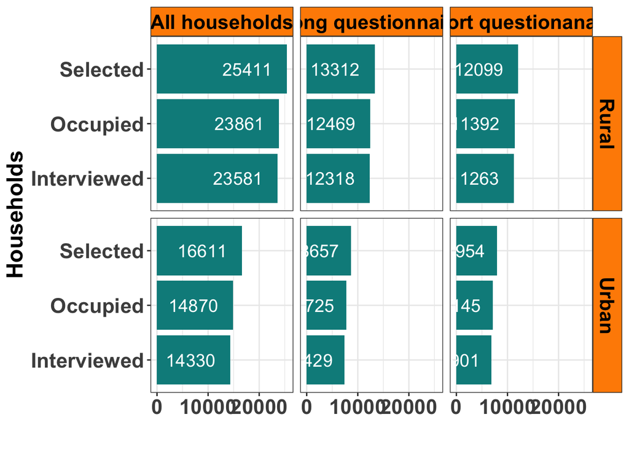

```r
interviewvisuals <- kdhshouseholdinterviews %>%
  ggplot(aes(x=Households, y=numbers)) +
  geom_bar(stat = "identity", position = position_dodge(), fill="cyan4") +
  theme_bw() +
  geom_text(aes(label=numbers), hjust=1.3, size=5, color="white")+
  coord_flip() +
  ylab("") + xlab("Households") +
  facet_grid(residence~selection) +
  theme(strip.text.x = element_text(size = 16, colour = "black", face = "bold")) +
  theme(strip.text.y = element_text(size = 16, colour = "black", face = "bold")) +
  theme(axis.title=element_text(size=18, face="bold"), axis.text = element_text(face = "bold", size = rel(1.5))) +
  theme(strip.background =element_rect(fill="darkorange"))

interviewvisuals
```

- Results of the participants that answered the questionnaire surveys

```r
## Results of participants
allwomen <- tbls[[3]] %>% #women age 15-49 years - from all households
  slice(14:15) %>%
  dplyr::select(V1,V2,V3) %>%
  dplyr::rename(Respondents = V1,
                Urban = V2,
                Rural = V3) %>%
  dplyr::mutate(selection = "All_households")

lqwomen <- tbls[[3]] %>% #women age 15-49 years - for the long questionnaire
  slice(27:28) %>%
  dplyr::select(V1,V2,V3) %>%
  dplyr::rename(Respondents = V1,
                Urban = V2,
                Rural = V3) %>%
  dplyr::mutate(selection = "Long_questionnaire")

sqwomen <- tbls[[3]] %>% #women age 15-49 years - for the short questionnaire
  slice(46:47) %>%
  dplyr::select(V1,V2,V3) %>%
  dplyr::rename(Respondents = V1,
                Urban = V2,
                Rural = V3) %>%
  dplyr::mutate(selection = "Short_questionnaire")

womeninterviews <- dplyr::bind_rows(allwomen,lqwomen,sqwomen) %>%
  tidyr::gather(residence,numbers,2:3) %>%
  dplyr::arrange(selection, residence) %>%
  mutate(Gender = "Female")

#womeninterviews
#write_csv(womeninterviews, "table1_womeninterviewed.csv") ## saves the .csv file of the women 15-59 years interviewed


lqmen <- tbls[[3]] %>% #men 15-54 years - for the long questionnaire
  slice(33:34) %>%
  dplyr::select(V1,V2,V3) %>%
  dplyr::rename(Respondents = V1,
                Urban = V2,
                Rural = V3) %>%
  dplyr::mutate(selection = "Long_questionnaire")

meninterviews <- lqmen %>%
  tidyr::gather(residence,numbers,2:3) %>%
  dplyr::arrange(selection, residence) %>%
  mutate(Gender = "Male")

#meninterviews
#write_csv(meninterviews, "table1_meninterviewed.csv") ## saves .csv file of the men 15-54years interviewed

participantsinterviews <- bind_rows(womeninterviews, meninterviews)
participantsinterviews
```

```
## # A tibble: 16 × 5
##    Respondents                          selection         resid…¹ numbers Gender
##    <chr>                                <chr>             <chr>   <chr>   <chr>
##  1 Number of eligible women             All_households    Rural   20,750  Female
##  2 Number of eligible women interviewed All_households    Rural   19,770  Female
##  3 Number of eligible women             All_households    Urban   13,129  Female
##  4 Number of eligible women interviewed All_households    Urban   12,386  Female
##  5 Number of eligible women             Long_questionnai… Rural   10,914  Female
##  6 Number of eligible women interviewed Long_questionnai… Rural   10,384  Female
##  7 Number of eligible women             Long_questionnai… Urban   6,911   Female
##  8 Number of eligible women interviewed Long_questionnai… Urban   6,517   Female
##  9 Number of eligible women             Short_questionna… Rural   9,836   Female
## 10 Number of eligible women interviewed Short_questionna… Rural   9,386   Female
## 11 Number of eligible women             Short_questionna… Urban   6,218   Female
## 12 Number of eligible women interviewed Short_questionna… Urban   5,869   Female
## 13 Number of eligible men               Long_questionnai… Rural   10,418  Male
## 14 Number of eligible men interviewed   Long_questionnai… Rural   9,221   Male
## 15 Number of eligible men               Long_questionnai… Urban   6,134   Male
## 16 Number of eligible men interviewed   Long_questionnai… Urban   5,232   Male
## # … with abbreviated variable name ¹residence
```

```r
write_csv(participantsinterviews, "table1_participantsinterviews.csv")  ## combines the data from women and men interviewed
```

- Visualizing information on the participant’s of the 2022 KDHS

```r
participantsinterviews <- read_csv("table1_participantsinterviews.csv") %>%
  dplyr::mutate(Participant = recode(Respondents, "Number of eligible women" = "Eligible women","Number of eligible women interviewed" = "Women interviewed", "Number of eligible men" = "Eligible men","Number of eligible men interviewed" = "Men interviewed"))
```

[figure not shown]

```r
womenparticipantsinterviewsvisuals <- participantsinterviews %>%
  dplyr::filter(Gender == "Female") %>%
  ggplot(aes(x=Respondents, y=numbers)) +
  geom_bar(stat = "identity", position = position_dodge(), fill="cyan4") +
  theme_bw() +
  geom_text(aes(label=numbers), hjust=1.3, size=5, color="white")+
  coord_flip() +
  ylab("") + xlab("Respondents") +
  facet_grid(residence~selection) +
  theme(strip.text.x = element_text(size = 16, colour = "black", face = "bold")) +
  theme(strip.text.y = element_text(size = 16, colour = "black", face = "bold")) +
  theme(axis.title=element_text(size=18, face="bold"), axis.text = element_text(face = "bold", size = rel(1.5))) +
  theme(strip.background =element_rect(fill="darkorange"))

womenparticipantsinterviewsvisuals
```

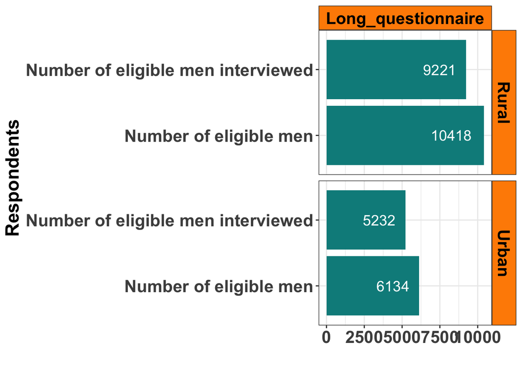

```r
menparticipantsinterviewsvisuals <- participantsinterviews %>%
  dplyr::filter(Gender == "Male") %>%
  ggplot(aes(x=Respondents, y=numbers)) +
  geom_bar(stat = "identity", position = position_dodge(), fill="cyan4") +
  theme_bw() +
  geom_text(aes(label=numbers), hjust=1.3, size=5, color="white")+
  coord_flip() +
  ylab("") + xlab("Respondents") +
  facet_grid(residence~selection) +
  theme(strip.text.x = element_text(size = 16, colour = "black", face = "bold")) +
  theme(strip.text.y = element_text(size = 16, colour = "black", face = "bold")) +
  theme(axis.title=element_text(size=18, face="bold"), axis.text = element_text(face = "bold", size = rel(1.5))) +
  theme(strip.background =element_rect(fill="darkorange"))

menparticipantsinterviewsvisuals
```

## 3.2 Characteristics of the respondents (Table 2 data)

- By age of the respondents

```r
## Ages of the respondents
table2agewomen <- tbls[[4]] %>% # table 2 of the DHS2022 report
  slice(6:12) %>% # select rows with ages
  dplyr::select(V1:V4) %>%
  dplyr::rename(Age = V1,
                Weighted_percent = V2,
                Weighted_number = V3,
                Unweighted_number = V4) %>%
  dplyr::mutate(Participants = "Women")

table2agemen <- tbls[[4]] %>% # table 2 of the DHS2022 report
  slice(6:12) %>% # select rows with ages
  dplyr::select(V1,V5:V7) %>%
  dplyr::rename(Age = V1,
                Weighted_percent = V5,
                Weighted_number = V6,
                Unweighted_number = V7) %>%
  dplyr::mutate(Participants = "Men")

ageparticipants <- bind_rows(table2agewomen,table2agemen)

ageparticipants
```

```
## # A tibble: 14 × 5
##    Age   Weighted_percent Weighted_number Unweighted_number Participants
##    <chr> <chr>            <chr>           <chr>             <chr>
##  1 15–19 18.7             6,025           6,404             Women
##  2 20–24 18.7             6,001           5,762             Women
##  3 25–29 17.7             5,687           5,443             Women
##  4 30–34 14.1             4,530           4,561             Women
##  5 35–39 13.4             4,311           4,354             Women
##  6 40–44 9.6              3,084           3,100             Women
##  7 45–49 7.8              2,518           2,532             Women
##  8 15–19 23.3             3,175           3,349             Men
##  9 20–24 17.6             2,404           2,332             Men
## 10 25–29 16.6             2,268           2,109             Men
## 11 30–34 13.1             1,787           1,748             Men
## 12 35–39 11.6             1,577           1,628             Men
## 13 40–44 9.8              1,332           1,386             Men
## 14 45–49 8.1              1,109           1,117             Men
```

```r
write_csv(ageparticipants, "table2_ageparticipants.csv")
```

- Visualizations of the respondents by age

```r
respondentsbyage <- read_csv("table2_ageparticipants.csv")
```

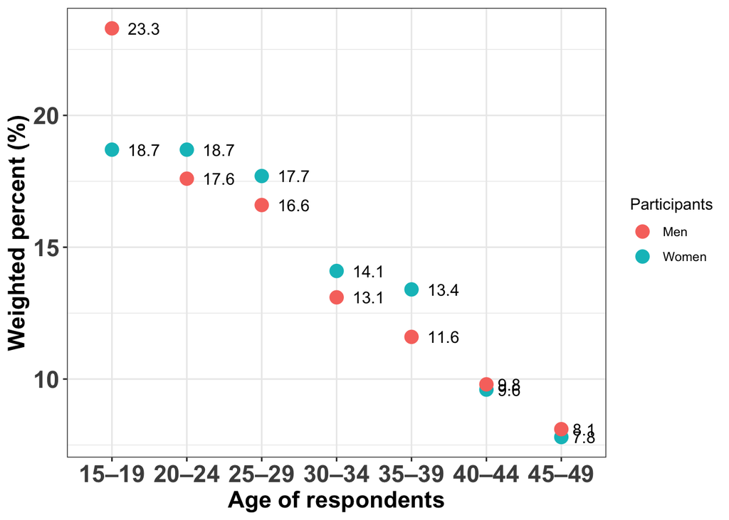

```r
respondentsbyagevisuals <- respondentsbyage %>%
  ggplot(aes(x=Age, y=Weighted_percent, color = Participants)) +
  geom_point(stat = "identity", size= 4) +
  theme_bw() +
  geom_text(aes(label=Weighted_percent), hjust=-0.5, size=4, color="black")+
  ylab("Weighted percent (%)") + xlab("Age of respondents") +
  theme(axis.title=element_text(size=16, face="bold"), axis.text = element_text(face = "bold", size = rel(1.5)))

respondentsbyagevisuals
```

- Data and visualizations for self reported health status by the DHS respondents

```r
## Self reported health status

selfreport_healthstatuswomen <- tbls[[4]] %>%
  slice(15:19) %>%
  select(V1:V4) %>%
  dplyr::rename(Health_status = V1,
                Weighted_percent = V2,
                Weighted_number = V3,
                Unweighted_number = V4) %>%
  dplyr::mutate(Participants = "Women")

selfreport_healthstatusmen <- tbls[[4]] %>%
  slice(15:19) %>%
  select(V1,V5:V7) %>%
  dplyr::rename(Health_status = V1,
                Weighted_percent = V5,
                Weighted_number = V6,
                Unweighted_number = V7) %>%
  dplyr::mutate(Participants = "Men")

selfreport_healthstatus <- bind_rows(selfreport_healthstatuswomen,selfreport_healthstatusmen)

selfreport_healthstatus
```

```
## # A tibble: 10 × 5
##    Health_status Weighted_percent Weighted_number Unweighted_number Participants
##    <chr>         <chr>            <chr>           <chr>             <chr>
##  1 Very good     23.8             7,638           7,867             Women
##  2 Good          55.4             17,823          17,988            Women
##  3 Moderate      18.4             5,933           5,541             Women
##  4 Bad           2.2              696             710               Women
##  5 Very bad      0.2              67              50                Women
##  6 Very good     35.8             4,883           5,098             Men
##  7 Good          48.9             6,677           6,607             Men
##  8 Moderate      14.1             1,926           1,799             Men
##  9 Bad           1.0              141             145               Men
## 10 Very bad      0.2              26              20                Men
```

```r
write_csv(selfreport_healthstatus, "table2_selfreport_healthstatus.csv")
```

- Visualization of reported health status by the respondents

```r
healthstatus <- read_csv("table2_selfreport_healthstatus.csv") %>%
  mutate(Health_status = fct_relevel(Health_status,
            "Very bad","Bad","Moderate","Good","Very good"))
```

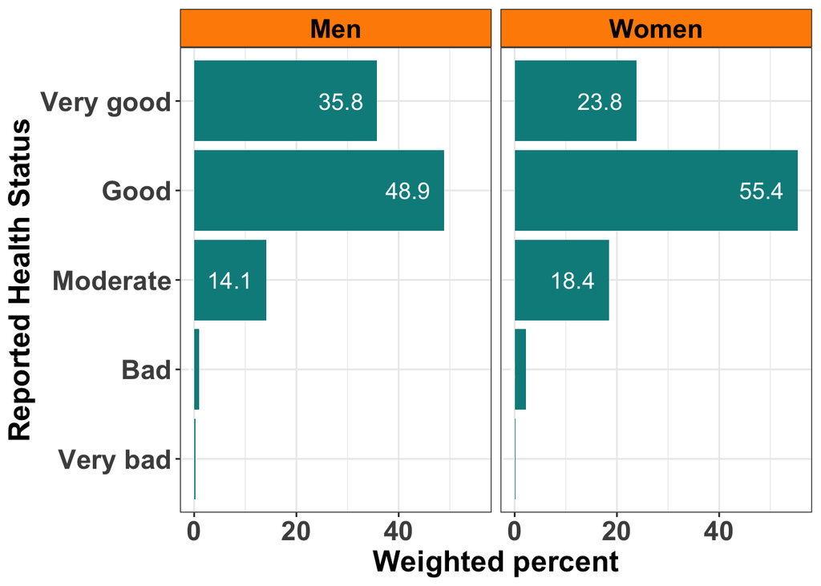

```r
healthstatusvisuals <- healthstatus %>%
  ggplot(aes(x=Health_status, y=Weighted_percent)) +
  geom_bar(stat = "identity", position = position_dodge(), fill="cyan4") +
  theme_bw() +
  geom_text(aes(label=Weighted_percent), hjust=1.3, size=5, color="white")+
  coord_flip() +
  ylab("Weighted percent") + xlab("Reported Health Status") +
  facet_wrap(~Participants) +
  theme(strip.text.x = element_text(size = 16, colour = "black", face = "bold")) +
  theme(strip.text.y = element_text(size = 16, colour = "black", face = "bold")) +
  theme(axis.title=element_text(size=18, face="bold"), axis.text = element_text(face = "bold", size = rel(1.5))) +
  theme(strip.background =element_rect(fill="darkorange"))

healthstatusvisuals
```

- Characteristics of the respondents by religion

```r
## Religion of the participants

religionwomen <- tbls[[4]] %>%
  slice(22:26) %>%
  select(V1:V4) %>%
  dplyr::rename(Religion = V1,
                Weighted_percent = V2,
                Weighted_number = V3,
                Unweighted_number = V4) %>%
  dplyr::mutate(Participants = "Women")

religionmen <- tbls[[4]] %>%
  slice(22:26) %>%
  select(V1,V5:V7) %>%
  dplyr::rename(Religion = V1,
                Weighted_percent = V5,
                Weighted_number = V6,
                Unweighted_number = V7) %>%
  dplyr::mutate(Participants = "Men")

religion <- bind_rows(religionwomen,religionmen)

religion
```

```
## # A tibble: 10 × 5
##    Religion                   Weighted_percent Weighted_number Unweigh…¹ Parti…²
##    <chr>                      <chr>            <chr>           <chr>     <chr>
##  1 Catholic                   18.6             5,978           5,665     Women
##  2 Protestant/other Christian 72.9             23,442          21,154    Women
##  3 Muslim                     7.1              2,275           4,852     Women
##  4 No religion                1.1              344             357       Women
##  5 Other                      0.4              117             128       Women
##  6 Catholic                   21.6             2,946           2,709     Men
##  7 Protestant/other Christian 66.0             9,006           8,137     Men
##  8 Muslim                     7.2              987             2,148     Men
##  9 No religion                4.4              607             557       Men
## 10 Other                      0.8              107             118       Men
## # … with abbreviated variable names ¹Unweighted_number, ²Participants
```

```r
write_csv(religion, "table2_religionparticipants.csv")
```

- Visualizations of the respondents characteristics by religion

```r
religionrespondents <- read_csv("table2_religionparticipants.csv") %>%
  mutate(Religion = fct_relevel(Religion, "Other","No religion", "Muslim","Catholic","Protestant/other Christian"))
```

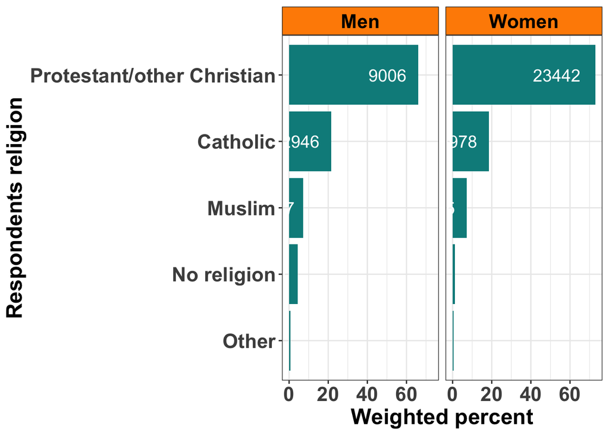

```r
religionrespondentsvisuals <- religionrespondents %>%
  ggplot(aes(x=Religion, y=Weighted_percent)) +
  geom_bar(stat = "identity", position = position_dodge(), fill="cyan4") +
  theme_bw() +
  geom_text(aes(label=Weighted_number), hjust=1.3, size=5, color="white")+
  coord_flip() +
  ylab("Weighted percent") + xlab("Respondents religion") +
  facet_wrap(~Participants) +
  theme(strip.text.x = element_text(size = 16, colour = "black", face = "bold")) +
  theme(strip.text.y = element_text(size = 16, colour = "black", face = "bold")) +
  theme(axis.title=element_text(size=18, face="bold"), axis.text = element_text(face = "bold", size = rel(1.5))) +
  theme(strip.background =element_rect(fill="darkorange"))

religionrespondentsvisuals
```

- Respondents characteristics based on marital status

```r
## Religion of the participants

maritalstatuswomen <- tbls[[4]] %>%
  slice(29:33) %>%
  select(V1:V4) %>%
  dplyr::rename(Marital_status = V1,
                Weighted_percent = V2,
                Weighted_number = V3,
                Unweighted_number = V4) %>%
  dplyr::mutate(Participants = "Women")

maritalstatusmen <- tbls[[4]] %>%
  slice(29:33) %>%
  select(V1,V5:V7) %>%
  dplyr::rename(Marital_status = V1,
                Weighted_percent = V5,
                Weighted_number = V6,
                Unweighted_number = V7) %>%
  dplyr::mutate(Participants = "Men")

maritalstatus <- bind_rows(maritalstatuswomen,maritalstatusmen)

maritalstatus
```

```
## # A tibble: 10 × 5
##    Marital_status     Weighted_percent Weighted_number Unweighted_number Parti…¹
##    <chr>              <chr>            <chr>           <chr>             <chr>
##  1 Never married      32.5             10,438          10,048            Women
##  2 Married            48.1             15,483          16,454            Women
##  3 Living together    7.3              2,339           1,858             Women
##  4 Divorced/separated 9.3              2,989           2,776             Women
##  5 Widowed            2.8              908             1,020             Women
##  6 Never married      48.2             6,576           6,486             Men
##  7 Married            43.3             5,907           5,994             Men
##  8 Living together    2.6              351             393               Men
##  9 Divorced/separated 5.6              771             748               Men
## 10 Widowed            0.4              49              48                Men
## # … with abbreviated variable name ¹Participants
```

```r
write_csv(maritalstatus, "table2_maritalstatusparticipants.csv")
```

- Visualization of the participants marital status

```r
maritalstatusrespondents <- read_csv("table2_maritalstatusparticipants.csv") %>%
  mutate(Marital_status = fct_relevel(Marital_status, "Widowed","Living together", "Divorced/separated","Never married","Married"))
```

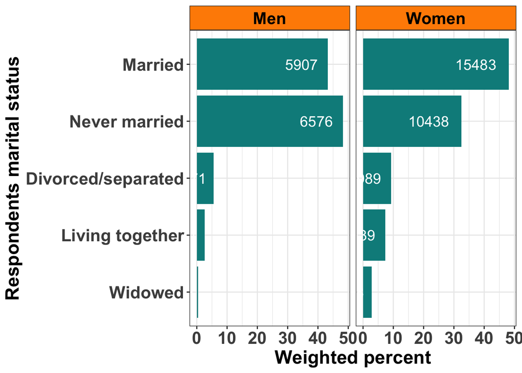

```r
maritalstatusrespondentsvisuals <- maritalstatusrespondents %>%
  ggplot(aes(x=Marital_status, y=Weighted_percent)) +
  geom_bar(stat = "identity", position = position_dodge(), fill="cyan4") +
  theme_bw() +
  geom_text(aes(label=Weighted_number), hjust=1.3, size=5, color="white")+
  coord_flip() +
  ylab("Weighted percent") + xlab("Respondents marital status") +
  facet_wrap(~Participants) +
  theme(strip.text.x = element_text(size = 16, colour = "black", face = "bold")) +
  theme(strip.text.y = element_text(size = 16, colour = "black", face = "bold")) +
  theme(axis.title=element_text(size=18, face="bold"), axis.text = element_text(face = "bold", size = rel(1.5))) +
  theme(strip.background =element_rect(fill="darkorange"))

maritalstatusrespondentsvisuals
```

- Participants residential places

```r
## Residence of the participants

residencewomen <- tbls[[4]] %>%
  slice(36:37) %>%
  select(V1:V4) %>%
  dplyr::rename(Residence = V1,
                Weighted_percent = V2,
                Weighted_number = V3,
                Unweighted_number = V4) %>%
  dplyr::mutate(Participants = "Women")

residencemen <- tbls[[4]] %>%
  slice(36:37) %>%
  select(V1,V5:V7) %>%
  dplyr::rename(Residence = V1,
                Weighted_percent = V5,
                Weighted_number = V6,
                Unweighted_number = V7) %>%
  dplyr::mutate(Participants = "Men")

residence <- bind_rows(residencewomen,residencemen)

residence
```

```
## # A tibble: 4 × 5
##   Residence Weighted_percent Weighted_number Unweighted_number Participants
##   <chr>     <chr>            <chr>           <chr>             <chr>
## 1 Urban     40.9             13,143          12,386            Women
## 2 Rural     59.1             19,013          19,770            Women
## 3 Urban     39.4             5,382           5,003             Men
## 4 Rural     60.6             8,270           8,666             Men
```

```r
write_csv(residence, "table2_residenceparticipants.csv")
```

- Visualization of the participants characteristics - by place of resident

```r
residentrespondents <- read_csv("table2_residenceparticipants.csv") %>%
  mutate(Residence = fct_relevel(Residence, "Urban", "Rural"))
```

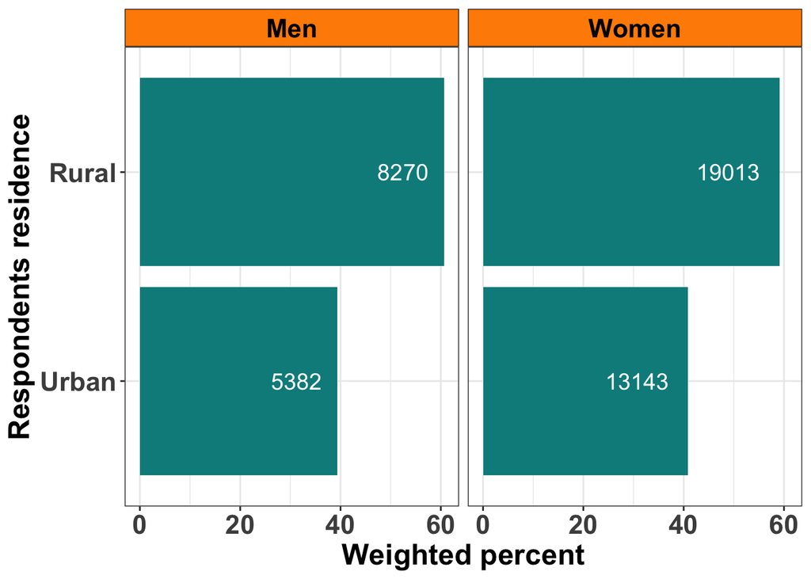

```r
residentrespondentsvisuals <- residentrespondents %>%
  ggplot(aes(x=Residence, y=Weighted_percent)) +
  geom_bar(stat = "identity", position = position_dodge(), fill="cyan4") +
  theme_bw() +
  geom_text(aes(label=Weighted_number), hjust=1.3, size=5, color="white")+
  coord_flip() +
  ylab("Weighted percent") + xlab("Respondents residence") +
  facet_wrap(~Participants) +
  theme(strip.text.x = element_text(size = 16, colour = "black", face = "bold")) +
  theme(strip.text.y = element_text(size = 16, colour = "black", face = "bold")) +
  theme(axis.title=element_text(size=18, face="bold"), axis.text = element_text(face = "bold", size = rel(1.5))) +
  theme(strip.background =element_rect(fill="darkorange"))

residentrespondentsvisuals
```

- Participants characteristics - by Education status

```r
## Education status of the participants

educationstatuswomen <- tbls[[4]] %>%
  slice(40:44) %>%
  select(V1:V4) %>%
  dplyr::rename(Education_status = V1,
                Weighted_percent = V2,
                Weighted_number = V3,
                Unweighted_number = V4) %>%
  dplyr::mutate(Participants = "Women")

educationstatusnmen <- tbls[[4]] %>%
  slice(40:44) %>%
  select(V1,V5:V7) %>%
  dplyr::rename(Education_status = V1,
                Weighted_percent = V5,
                Weighted_number = V6,
                Unweighted_number = V7) %>%
  dplyr::mutate(Participants = "Men")

educationstatus <- bind_rows(educationstatuswomen,educationstatusnmen)

educationstatus
```

```
## # A tibble: 10 × 5
##    Education_status    Weighted_percent Weighted_number Unweighted_num…¹ Parti…²
##    <chr>               <chr>            <chr>           <chr>            <chr>
##  1 No education        5.5              1,770           3,836            Women
##  2 Primary             36.3             11,687          11,807           Women
##  3 Secondary           38.0             12,204          11,311           Women
##  4 Vocational          1.1              345             323              Women
##  5 More than secondary 19.1             6,150           4,879            Women
##  6 No education        2.7              369             774              Men
##  7 Primary             35.9             4,894           5,150            Men
##  8 Secondary           39.5             5,386           5,195            Men
##  9 Vocational          1.5              206             204              Men
## 10 More than secondary 20.5             2,797           2,346            Men
## # … with abbreviated variable names ¹Unweighted_number, ²Participants
```

```r
write_csv(educationstatus, "table2_educationstatusparticipants.csv")
```

- Visualizations by the education status of the respondents

```r
educationrespondents <- read_csv("table2_educationstatusparticipants.csv")  %>%
  mutate(Education_status = fct_relevel(Education_status, "Vocational", "More than secondary","Secondary", "Primary", "No education"))
```

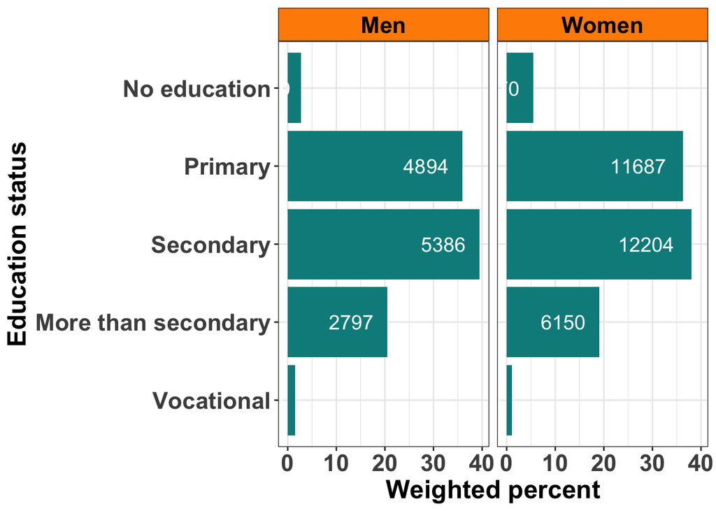

```r
educationrespondentsvisuals <- educationrespondents %>%
  ggplot(aes(x=Education_status, y=Weighted_percent)) +
  geom_bar(stat = "identity", position = position_dodge(), fill="cyan4") +
  theme_bw() +
  geom_text(aes(label=Weighted_number), hjust=1.3, size=5, color="white")+
  coord_flip() +
  ylab("Weighted percent") + xlab("Education status") +
  facet_wrap(~Participants) +
  theme(strip.text.x = element_text(size = 16, colour = "black", face = "bold")) +
  theme(strip.text.y = element_text(size = 16, colour = "black", face = "bold")) +
  theme(axis.title=element_text(size=18, face="bold"), axis.text = element_text(face = "bold", size = rel(1.5))) +
  theme(strip.background =element_rect(fill="darkorange"))

educationrespondentsvisuals
```

- Respondents by their Wealth quintile

```r
## Economic status of the participants (wealth quintiles) for those aged 15-49 - men and women

economicstatuswomen <- tbls[[5]] %>%
  slice(5:9) %>%
  select(V1:V4) %>%
  dplyr::rename(Wealth_quintile = V1,
                Weighted_percent = V2,
                Weighted_number = V3,
                Unweighted_number = V4) %>%
  dplyr::mutate(Participants = "Women")

economicstatusnmen <- tbls[[5]] %>%
  slice(5:9) %>%
  select(V1,V5:V7) %>%
  dplyr::rename(Wealth_quintile = V1,
                Weighted_percent = V5,
                Weighted_number = V6,
                Unweighted_number = V7) %>%
  dplyr::mutate(Participants = "Men")

economicstatus15_49 <- bind_rows(economicstatuswomen,economicstatusnmen)

economicstatus15_49
```

```
## # A tibble: 10 × 5
##    Wealth_quintile Weighted_percent Weighted_number Unweighted_number Particip…¹
##    <chr>           <chr>            <chr>           <chr>             <chr>
##  1 Lowest          15.6             5,019           7,073             Women
##  2 Second          17.7             5,698           5,742             Women
##  3 Middle          18.9             6,069           6,345             Women
##  4 Fourth          22.2             7,139           7,160             Women
##  5 Highest         25.6             8,231           5,836             Women
##  6 Lowest          15.1             2,062           2,881             Men
##  7 Second          18.9             2,584           2,660             Men
##  8 Middle          20.2             2,754           2,873             Men
##  9 Fourth          24.4             3,325           3,138             Men
## 10 Highest         21.4             2,927           2,117             Men
## # … with abbreviated variable name ¹Participants
```

```r
write_csv(economicstatus15_49, "table2_economicstatus15_49.csv")
```

- Visualization for participants by the wealth quintile

```r
economicstatusrespondents <- read_csv("table2_economicstatus15_49.csv")  %>%
  mutate(Wealth_quintile = fct_relevel(Wealth_quintile, "Lowest", "Second","Middle", "Fourth", "Highest"))
```

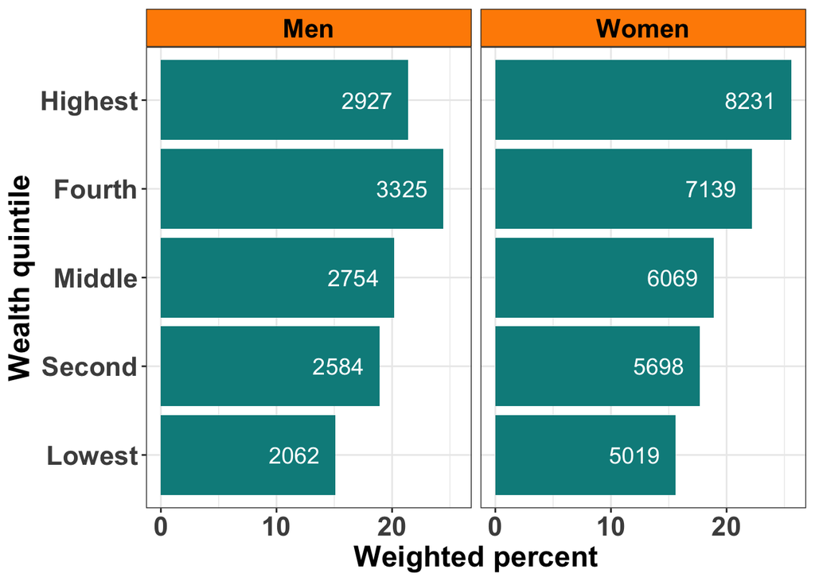

```r
economicstatusrespondentsvisuals <- economicstatusrespondents %>%
  ggplot(aes(x=Wealth_quintile, y=Weighted_percent)) +
  geom_bar(stat = "identity", position = position_dodge(), fill="cyan4") +
  theme_bw() +
  geom_text(aes(label=Weighted_number), hjust=1.3, size=5, color="white")+
  coord_flip() +
  ylab("Weighted percent") + xlab("Wealth quintile") +
  facet_wrap(~Participants) +
  theme(strip.text.x = element_text(size = 16, colour = "black", face = "bold")) +
  theme(strip.text.y = element_text(size = 16, colour = "black", face = "bold")) +
  theme(axis.title=element_text(size=18, face="bold"), axis.text = element_text(face = "bold", size = rel(1.5))) +
  theme(strip.background =element_rect(fill="darkorange"))

economicstatusrespondentsvisuals
```

### Participants distribution by County

```r
## Participants distribution by county (for those aged 15-49 years)

womenbycounty <- tbls[[6]] %>%
  slice(5:51) %>%
  select(V1:V4) %>%
  dplyr::rename(County = V1,
                Weighted_percent = V2,
                Weighted_number = V3,
                Unweighted_number = V4) %>%
  dplyr::mutate(Participants = "Women")

menbycounty <- tbls[[6]] %>%
  slice(5:51) %>%
  select(V1,V5:V7) %>%
  dplyr::rename(County = V1,
                Weighted_percent = V5,
                Weighted_number = V6,
                Unweighted_number = V7) %>%
  dplyr::mutate(Participants = "Men")

participantsbycounty <- bind_rows(womenbycounty,menbycounty)

participantsbycounty
```

```
## # A tibble: 94 × 5
##    County       Weighted_percent Weighted_number Unweighted_number Participants
##    <chr>        <chr>            <chr>           <chr>             <chr>
##  1 Mombasa      2.9              947             749               Women
##  2 Kwale        1.5              498             711               Women
##  3 Kilifi       2.9              928             742               Women
##  4 Tana River   0.5              149             641               Women
##  5 Lamu         0.3              101             675               Women
##  6 Taita/Taveta 0.7              234             483               Women
##  7 Garissa      0.9              290             641               Women
##  8 Wajir        0.5              160             745               Women
##  9 Mandera      0.6              206             723               Women
## 10 Marsabit     0.4              129             535               Women
## # … with 84 more rows
```

```r
write_csv(participantsbycounty, "table2_participantsbycounty.csv")
```

- Visualizations of participants by county

```r
countyrespondents <- read_csv("table2_participantsbycounty.csv") %>%
  arrange(desc(Weighted_percent))
```

[figure not shown]

```r
countyrespondentsvisuals <- countyrespondents %>%
  arrange(desc(Weighted_percent)) %>%
  ggplot(aes(x=reorder(County,Weighted_percent), y=Weighted_percent)) +
  geom_bar(stat = "identity", position = position_dodge(), fill="cyan4") +
  theme_bw() +
  geom_text(aes(label=Weighted_number), hjust=1.3, size=5, color="white")+
  coord_flip() +
  ylab("Weighted percent") + xlab("County") +
  facet_wrap(~Participants) +
  theme(strip.text.x = element_text(size = 12, colour = "black", face = "bold")) +
  theme(strip.text.y = element_text(size = 12, colour = "black", face = "bold")) +
  theme(axis.title=element_text(size=14, face="bold"), axis.text = element_text(face = "bold", size = rel(1.5))) +
  theme(strip.background =element_rect(fill="darkorange"))

countyrespondentsvisuals
```

## Health Insurance Coverage - Table 3

### By Age Category

```r
## Health Insurance Coverage by age category

healthinsurancebyage_women <- tbls[[7]] %>%
  slice(6:8) %>%
  select(V1:V8) %>%
  dplyr::rename(Age_category = V1,
                NHIF = V2,
                Private_commercial = V3,
                Community_based = V4,
                Other = V5,
                None_DontKnow = V6,
                Any_health_insurance = V7,
                Number_of_people = V8) %>%
  dplyr::mutate(Participants = "Women")

healthinsurancebyage_men <- tbls[[7]] %>%
  slice(6:8) %>%
  select(V1,V9:V15) %>%
  dplyr::rename(Age_category = V1,
                NHIF = V9,
                Private_commercial = V10,
                Community_based = V11,
                Other = V12,
                None_DontKnow = V13,
                Any_health_insurance = V14,
                Number_of_people = V15) %>%
  dplyr::mutate(Participants = "Men")

healthinsurancebyage <- bind_rows(healthinsurancebyage_women,healthinsurancebyage_men)

healthinsurancebyage
```

```
## # A tibble: 6 × 9
##   Age_category NHIF  Private_com…¹ Commu…² Other None_…³ Any_h…⁴ Numbe…⁵ Parti…⁶
##   <chr>        <chr> <chr>         <chr>   <chr> <chr>   <chr>   <chr>   <chr>
## 1 0–14         18.9  3.0           0.6     0.1   79.1    20.9    14,467  Women
## 2 15–49        26.0  4.4           0.5     0.1   71.3    28.7    18,142  Women
## 3 50+          27.8  4.0           1.2     0.0   69.1    30.9    5,087   Women
## 4 0–14         18.8  3.3           0.5     0.0   79.2    20.8    14,514  Men
## 5 15–49        26.2  4.6           0.4     0.0   71.2    28.8    16,878  Men
## 6 50+          33.8  5.6           1.0     0.1   62.9    37.1    4,323   Men
## # … with abbreviated variable names ¹Private_commercial, ²Community_based,
## #   ³None_DontKnow, ⁴Any_health_insurance, ⁵Number_of_people, ⁶Participants
```

```r
write_csv(healthinsurancebyage, "table3_healthinsurancebyage.csv")
```

### By residence

```r
## Health Insurance Coverage by residence

healthinsurancebyresidence_women <- tbls[[7]] %>%
  slice(11:12) %>%
  select(V1:V8) %>%
  dplyr::rename(Residence = V1,
                NHIF = V2,
                Private_commercial = V3,
                Community_based = V4,
                Other = V5,
                None_DontKnow = V6,
                Any_health_insurance = V7,
                Number_of_people = V8) %>%
  dplyr::mutate(Participants = "Women")

healthinsurancebyresidence_men <- tbls[[7]] %>%
  slice(11:12) %>%
  select(V1,V9:V15) %>%
  dplyr::rename(Residence= V1,
                NHIF = V9,
                Private_commercial = V10,
                Community_based = V11,
                Other = V12,
                None_DontKnow = V13,
                Any_health_insurance = V14,
                Number_of_people = V15) %>%
  dplyr::mutate(Participants = "Men")

healthinsurancebyresidence <- bind_rows(healthinsurancebyresidence_women,healthinsurancebyresidence_men)

healthinsurancebyresidence
```

```
## # A tibble: 4 × 9
##   Residence NHIF  Private_commer…¹ Commu…² Other None_…³ Any_h…⁴ Numbe…⁵ Parti…⁶
##   <chr>     <chr> <chr>            <chr>   <chr> <chr>   <chr>   <chr>   <chr>
## 1 Urban     35.3  6.8              0.2     0.0   61.1    38.9    12,695  Women
## 2 Rural     17.5  2.3              0.9     0.1   80.5    19.5    25,025  Women
## 3 Urban     37.5  7.9              0.2     0.0   58.8    41.2    11,778  Men
## 4 Rural     17.5  2.4              0.7     0.0   80.6    19.4    23,967  Men
## # … with abbreviated variable names ¹Private_commercial, ²Community_based,
## #   ³None_DontKnow, ⁴Any_health_insurance, ⁵Number_of_people, ⁶Participants
```

```r
write_csv(healthinsurancebyresidence, "table3_healthinsurancebyresidence.csv")
```

### By wealth quintile

```r
## Health Insurance Coverage by wealth quintile

healthinsurancebywealthquintile_women <- tbls[[7]] %>%
  slice(15:19) %>%
  select(V1:V8) %>%
  dplyr::rename(Wealth_quintile = V1,
                NHIF = V2,
                Private_commercial = V3,
                Community_based = V4,
                Other = V5,
                None_DontKnow = V6,
                Any_health_insurance = V7,
                Number_of_people = V8) %>%
  dplyr::mutate(Participants = "Women")

healthinsurancebywealthquintile_men <- tbls[[7]] %>%
  slice(15:19) %>%
  select(V1,V9:V15) %>%
  dplyr::rename(Wealth_quintile= V1,
                NHIF = V9,
                Private_commercial = V10,
                Community_based = V11,
                Other = V12,
                None_DontKnow = V13,
                Any_health_insurance = V14,
                Number_of_people = V15) %>%
  dplyr::mutate(Participants = "Men")

healthinsurancebywealthquintile <- bind_rows(healthinsurancebywealthquintile_women,healthinsurancebywealthquintile_men)

healthinsurancebywealthquintile
```

```
## # A tibble: 10 × 9
##    Wealth_quintile NHIF  Private…¹ Commu…² Other None_…³ Any_h…⁴ Numbe…⁵ Parti…⁶
##    <chr>           <chr> <chr>     <chr>   <chr> <chr>   <chr>   <chr>   <chr>
##  1 Lowest          3.6   0.4       1.0     0.0   95.0    5.0     7,446   Women
##  2 Second          10.7  0.7       0.7     0.1   88.0    12.0    7,616   Women
##  3 Middle          20.0  1.4       0.9     0.1   78.3    21.7    7,334   Women
##  4 Fourth          31.4  4.2       0.5     0.0   66.2    33.8    7,463   Women
##  5 Highest         50.4  11.9      0.1     0.0   43.8    56.2    7,861   Women
##  6 Lowest          3.6   0.3       0.9     0.0   95.3    4.7     7,172   Men
##  7 Second          11.2  0.6       0.5     0.0   87.9    12.1    7,134   Men
##  8 Middle          19.9  1.8       0.6     0.1   78.4    21.6    7,190   Men
##  9 Fourth          33.2  4.3       0.4     0.0   64.0    36.0    7,521   Men
## 10 Highest         54.0  14.5      0.2     0.0   40.1    59.9    6,728   Men
## # … with abbreviated variable names ¹Private_commercial, ²Community_based,
## #   ³None_DontKnow, ⁴Any_health_insurance, ⁵Number_of_people, ⁶Participants
```

```r
write_csv(healthinsurancebywealthquintile, "table3_healthinsurancebyresidence.csv")
```

## Disability among household populations (Table 4)

### Disability by age

```r
disabilitywomenbyage <- tbls[[9]] %>% ## Extracted Table 9 - has information on disability by women
  slice(6:8) %>% #Age data rows
  dplyr::rename(Age_category = V1,
                No_difficulty = V2,
                Seeing = V3,
                Hearing = V4,
                Communicating = V5,
                Remembering_concentrating = V6,
                Walking_ClimbingSteps = V7,
                WashingAllOver_dressing = V8,
                SomeDifficulty = V9,
                A_lot_of_difficulty = V10,
                Cannot_do_at_all = V11,
                A_lot_of_difficulty_cannot_do_at_all = V12,
                A_lot_of_difficulty_cannot_do_at_all_more_than_one_domain = V13,
                Number = V14) %>%
  dplyr::mutate(Participants = "Women")

disabilitymenbyage <- tbls[[10]] %>% ## Extracted Table 10 - has information on disability by men
  slice(6:8) %>% # Age data rows
  dplyr::rename(Age_category = V1,
                No_difficulty = V2,
                Seeing = V3,
                Hearing = V4,
                Communicating = V5,
                Remembering_concentrating = V6,
                Walking_ClimbingSteps = V7,
                WashingAllOver_dressing = V8,
                SomeDifficulty = V9,
                A_lot_of_difficulty = V10,
                Cannot_do_at_all = V11,
                A_lot_of_difficulty_cannot_do_at_all = V12,
                A_lot_of_difficulty_cannot_do_at_all_more_than_one_domain = V13,
                Number = V14) %>%
  dplyr::mutate(Participants = "Men")

disabilitybyage <- bind_rows(disabilitywomenbyage,disabilitymenbyage)

disabilitybyage
```

```
## # A tibble: 6 × 15
##   Age_c…¹ No_di…² Seeing Hearing Commu…³ Remem…⁴ Walki…⁵ Washi…⁶ SomeD…⁷ A_lot…⁸
##   <chr>   <chr>   <chr>  <chr>   <chr>   <chr>   <chr>   <chr>   <chr>   <chr>
## 1 5–14    90.5    3.4    2.5     1.1     2.0     1.1     1.5     7.3     1.7
## 2 15–49   83.3    9.7    2.5     1.0     3.5     4.5     1.1     13.6    2.7
## 3 50+     37.0    38.8   15.5    3.5     23.0    41.2    13.7    40.7    20.5
## 4 5–14    89.1    3.4    2.5     1.7     2.5     1.5     2.6     7.8     2.1
## 5 15–49   86.1    6.9    2.1     1.4     3.3     3.4     1.2     10.8    2.6
## 6 50+     48.8    34.0   11.5    3.3     14.6    23.6    8.8     36.8    12.6
## # … with 5 more variables: Cannot_do_at_all <chr>,
## #   A_lot_of_difficulty_cannot_do_at_all <chr>,
## #   A_lot_of_difficulty_cannot_do_at_all_more_than_one_domain <chr>,
## #   Number <chr>, Participants <chr>, and abbreviated variable names
## #   ¹Age_category, ²No_difficulty, ³Communicating, ⁴Remembering_concentrating,
## #   ⁵Walking_ClimbingSteps, ⁶WashingAllOver_dressing, ⁷SomeDifficulty,
## #   ⁸A_lot_of_difficulty
```

```r
write_csv(disabilitybyage, "table4_disabilitybyage.csv")
```

### Disability by marital status

```r
disabilitywomenbymaritalstatus <- tbls[[9]] %>% ## Extracted Table 9 - has information on disability by women
  slice(11:15) %>% #marital status data rows
  dplyr::rename(Marital_status = V1,
                No_difficulty = V2,
                Seeing = V3,
                Hearing = V4,
                Communicating = V5,
                Remembering_concentrating = V6,
                Walking_ClimbingSteps = V7,
                WashingAllOver_dressing = V8,
                SomeDifficulty = V9,
                A_lot_of_difficulty = V10,
                Cannot_do_at_all = V11,
                A_lot_of_difficulty_cannot_do_at_all = V12,
                A_lot_of_difficulty_cannot_do_at_all_more_than_one_domain = V13,
                Number = V14) %>%
  dplyr::mutate(Participants = "Women")

disabilitymenbymaritalstatus <- tbls[[10]] %>% ## Extracted Table 10 - has information on disability by men
  slice(11:15) %>% # marital status data rows
  dplyr::rename(Marital_status = V1,
                No_difficulty = V2,
                Seeing = V3,
                Hearing = V4,
                Communicating = V5,
                Remembering_concentrating = V6,
                Walking_ClimbingSteps = V7,
                WashingAllOver_dressing = V8,
                SomeDifficulty = V9,
                A_lot_of_difficulty = V10,
                Cannot_do_at_all = V11,
                A_lot_of_difficulty_cannot_do_at_all = V12,
                A_lot_of_difficulty_cannot_do_at_all_more_than_one_domain = V13,
                Number = V14) %>%
  dplyr::mutate(Participants = "Men")

disabilitybymaritalstatus <- bind_rows(disabilitywomenbymaritalstatus,disabilitymenbymaritalstatus)

disabilitybymaritalstatus
```

```
## # A tibble: 10 × 15
##    Marital_status No_di…¹ Seeing Hearing Commu…² Remem…³ Walki…⁴ Washi…⁵ SomeD…⁶
##    <chr>          <chr>   <chr>  <chr>   <chr>   <chr>   <chr>   <chr>   <chr>
##  1 Never married  84.6    9.2    2.8     1.8     2.8     3.7     1.5     11.7
##  2 Married/livin… 75.8    14.3   3.9     0.8     6.3     10.6    2.5     19.2
##  3 Widowed        32.1    42.8   19.8    4.9     27.6    45.9    17.9    39.4
##  4 Divorced/sepa… 68.0    17.6   5.0     1.2     9.8     14.4    3.3     24.2
##  5 Not asked/mis… 90.4    3.5    2.5     1.1     2.1     1.2     1.5     7.3
##  6 Never married  88.0    5.2    2.3     1.9     3.5     2.8     1.6     8.5
##  7 Married/livin… 73.6    16.7   4.8     1.5     6.2     9.7     3.0     20.3
##  8 Widowed        39.2    39.0   16.0    4.3     20.4    35.7    18.8    39.7
##  9 Divorced/sepa… 68.4    15.0   6.2     2.5     10.3    12.1    4.3     23.0
## 10 Not asked/mis… 89.1    3.4    2.5     1.7     2.5     1.5     2.6     7.8
## # … with 6 more variables: A_lot_of_difficulty <chr>, Cannot_do_at_all <chr>,
## #   A_lot_of_difficulty_cannot_do_at_all <chr>,
## #   A_lot_of_difficulty_cannot_do_at_all_more_than_one_domain <chr>,
## #   Number <chr>, Participants <chr>, and abbreviated variable names
## #   ¹No_difficulty, ²Communicating, ³Remembering_concentrating,
## #   ⁴Walking_ClimbingSteps, ⁵WashingAllOver_dressing, ⁶SomeDifficulty
```

```r
write_csv(disabilitybymaritalstatus, "table4_disabilitybymaritalstatus.csv")
```

### Disability by residence

```r
disabilitywomenbyresidence <- tbls[[9]] %>% ## Extracted Table 9 - has information on disability by women
  slice(18:19) %>% # residence data rows
  dplyr::rename(Residence = V1,
                No_difficulty = V2,
                Seeing = V3,
                Hearing = V4,
                Communicating = V5,
                Remembering_concentrating = V6,
                Walking_ClimbingSteps = V7,
                WashingAllOver_dressing = V8,
                SomeDifficulty = V9,
                A_lot_of_difficulty = V10,
                Cannot_do_at_all = V11,
                A_lot_of_difficulty_cannot_do_at_all = V12,
                A_lot_of_difficulty_cannot_do_at_all_more_than_one_domain = V13,
                Number = V14) %>%
  dplyr::mutate(Participants = "Women")

disabilitymenbyresidence <- tbls[[10]] %>% ## Extracted Table 10 - has information on disability by men
  slice(18:19) %>% # residence data rows
  dplyr::rename(Residence = V1,
                No_difficulty = V2,
                Seeing = V3,
                Hearing = V4,
                Communicating = V5,
                Remembering_concentrating = V6,
                Walking_ClimbingSteps = V7,
                WashingAllOver_dressing = V8,
                SomeDifficulty = V9,
                A_lot_of_difficulty = V10,
                Cannot_do_at_all = V11,
                A_lot_of_difficulty_cannot_do_at_all = V12,
                A_lot_of_difficulty_cannot_do_at_all_more_than_one_domain = V13,
                Number = V14) %>%
  dplyr::mutate(Participants = "Men")

disabilitybyresidence <- bind_rows(disabilitywomenbyresidence,disabilitymenbyresidence)

disabilitybyresidence
```

```
## # A tibble: 4 × 15
##   Resid…¹ No_di…² Seeing Hearing Commu…³ Remem…⁴ Walki…⁵ Washi…⁶ SomeD…⁷ A_lot…⁸
##   <chr>   <chr>   <chr>  <chr>   <chr>   <chr>   <chr>   <chr>   <chr>   <chr>
## 1 Urban   83.9    10.2   2.6     1.0     2.9     5.6     1.7     12.5    3.2
## 2 Rural   75.3    13.5   5.5     1.6     7.8     11.1    4.0     17.7    6.2
## 3 Urban   86.1    8.2    1.9     1.0     2.5     3.4     1.4     11.6    1.8
## 4 Rural   79.8    10.3   4.4     2.1     5.6     6.7     3.4     14.4    4.9
## # … with 5 more variables: Cannot_do_at_all <chr>,
## #   A_lot_of_difficulty_cannot_do_at_all <chr>,
## #   A_lot_of_difficulty_cannot_do_at_all_more_than_one_domain <chr>,
## #   Number <chr>, Participants <chr>, and abbreviated variable names
## #   ¹Residence, ²No_difficulty, ³Communicating, ⁴Remembering_concentrating,
## #   ⁵Walking_ClimbingSteps, ⁶WashingAllOver_dressing, ⁷SomeDifficulty,
## #   ⁸A_lot_of_difficulty
```

```r
write_csv(disabilitybyresidence, "table4_disabilitybyresidence.csv")
```

### Disability by Education Status

```r
disabilitywomenbyeducationstatus <- tbls[[9]] %>% ## Extracted Table 9 - has information on disability by women
  slice(22:25) %>% # Education status data rows
  dplyr::rename(Education_status = V1,
                No_difficulty = V2,
                Seeing = V3,
                Hearing = V4,
                Communicating = V5,
                Remembering_concentrating = V6,
                Walking_ClimbingSteps = V7,
                WashingAllOver_dressing = V8,
                SomeDifficulty = V9,
                A_lot_of_difficulty = V10,
                Cannot_do_at_all = V11,
                A_lot_of_difficulty_cannot_do_at_all = V12,
                A_lot_of_difficulty_cannot_do_at_all_more_than_one_domain = V13,
                Number = V14) %>%
  dplyr::mutate(Participants = "Women")

disabilitymenbyeducationstatus <- tbls[[10]] %>% ## Extracted Table 10 - has information on disability by men
  slice(22:25) %>% # Educcation status data rows
  dplyr::rename(Education_status= V1,
                No_difficulty = V2,
                Seeing = V3,
                Hearing = V4,
                Communicating = V5,
                Remembering_concentrating = V6,
                Walking_ClimbingSteps = V7,
                WashingAllOver_dressing = V8,
                SomeDifficulty = V9,
                A_lot_of_difficulty = V10,
                Cannot_do_at_all = V11,
                A_lot_of_difficulty_cannot_do_at_all = V12,
                A_lot_of_difficulty_cannot_do_at_all_more_than_one_domain = V13,
                Number = V14) %>%
  dplyr::mutate(Participants = "Men")

disabilitybyeducationstatus <- bind_rows(disabilitywomenbyeducationstatus,disabilitymenbyeducationstatus)

disabilitybyeducationstatus
```

```
## # A tibble: 8 × 15
##   Educa…¹ No_di…² Seeing Hearing Commu…³ Remem…⁴ Walki…⁵ Washi…⁶ SomeD…⁷ A_lot…⁸
##   <chr>   <chr>   <chr>  <chr>   <chr>   <chr>   <chr>   <chr>   <chr>   <chr>
## 1 No edu… 67.3    17.3   10.6    4.0     12.7    19.0    10.3    19.4    11.3
## 2 Primary 77.9    11.8   4.4     1.1     6.5     9.2     2.6     16.5    5.2
## 3 Second… 82.6    11.2   2.2     0.7     3.1     5.7     1.0     14.1    2.9
## 4 More t… 84.8    11.1   1.7     0.6     2.1     3.9     0.8     13.5    1.7
## 5 No edu… 77.2    10.0   5.6     4.1     6.3     8.9     8.0     13.7    6.1
## 6 Primary 81.4    9.1    4.0     1.9     5.4     5.9     2.6     13.6    4.3
## 7 Second… 83.7    9.8    2.4     1.0     3.3     4.4     1.3     13.1    2.8
## 8 More t… 84.6    10.6   2.0     0.4     2.3     3.8     0.8     13.3    1.9
## # … with 5 more variables: Cannot_do_at_all <chr>,
## #   A_lot_of_difficulty_cannot_do_at_all <chr>,
## #   A_lot_of_difficulty_cannot_do_at_all_more_than_one_domain <chr>,
## #   Number <chr>, Participants <chr>, and abbreviated variable names
## #   ¹Education_status, ²No_difficulty, ³Communicating,
## #   ⁴Remembering_concentrating, ⁵Walking_ClimbingSteps,
## #   ⁶WashingAllOver_dressing, ⁷SomeDifficulty, ⁸A_lot_of_difficulty
```

```r
write_csv(disabilitybyeducationstatus, "table4_disabilitybyeducationstatus.csv")
```

### Disability by Wealth quintile

```r
disabilitywomenbywealthquintile <- tbls[[9]] %>% ## Extracted Table 9 - has information on disability by women
  slice(28:32) %>% # wealth quintile data rows
  dplyr::rename(Wealth_quintile = V1,
                No_difficulty = V2,
                Seeing = V3,
                Hearing = V4,
                Communicating = V5,
                Remembering_concentrating = V6,
                Walking_ClimbingSteps = V7,
                WashingAllOver_dressing = V8,
                SomeDifficulty = V9,
                A_lot_of_difficulty = V10,
                Cannot_do_at_all = V11,
                A_lot_of_difficulty_cannot_do_at_all = V12,
                A_lot_of_difficulty_cannot_do_at_all_more_than_one_domain = V13,
                Number = V14) %>%
  dplyr::mutate(Participants = "Women")

disabilitymenbywealthquintile <- tbls[[10]] %>% ## Extracted Table 10 - has information on disability by men
  slice(28:32) %>% # wealth quintile data rows
  dplyr::rename(Wealth_quintile= V1,
                No_difficulty = V2,
                Seeing = V3,
                Hearing = V4,
                Communicating = V5,
                Remembering_concentrating = V6,
                Walking_ClimbingSteps = V7,
                WashingAllOver_dressing = V8,
                SomeDifficulty = V9,
                A_lot_of_difficulty = V10,
                Cannot_do_at_all = V11,
                A_lot_of_difficulty_cannot_do_at_all = V12,
                A_lot_of_difficulty_cannot_do_at_all_more_than_one_domain = V13,
                Number = V14) %>%
  dplyr::mutate(Participants = "Men")

disabilitybywealthquintile <- bind_rows(disabilitywomenbywealthquintile,disabilitymenbywealthquintile)

disabilitybywealthquintile
```

```
## # A tibble: 10 × 15
##    Wealth_quint…¹ No_di…² Seeing Hearing Commu…³ Remem…⁴ Walki…⁵ Washi…⁶ SomeD…⁷
##    <chr>          <chr>   <chr>  <chr>   <chr>   <chr>   <chr>   <chr>   <chr>
##  1 Lowest         75.4    12.8   7.2     2.2     8.5     10.9    4.8     16.4
##  2 Second         74.6    13.8   5.9     1.5     8.5     11.1    3.4     18.2
##  3 Middle         75.8    13.4   4.3     1.4     7.1     11.7    3.9     17.6
##  4 Fourth         79.8    11.8   3.1     1.2     4.3     8.5     2.8     15.8
##  5 Highest        85.1    10.3   2.1     0.9     2.4     4.4     1.2     12.0
##  6 Lowest         79.9    9.9    5.4     2.7     6.0     7.4     4.3     13.3
##  7 Second         78.3    10.2   4.7     2.2     6.6     6.8     3.4     15.2
##  8 Middle         81.0    10.4   3.4     1.8     4.8     6.2     2.8     14.0
##  9 Fourth         83.5    9.1    2.5     1.3     3.5     4.8     2.0     13.1
## 10 Highest        86.8    8.2    1.7     0.7     2.1     2.7     1.0     11.4
## # … with 6 more variables: A_lot_of_difficulty <chr>, Cannot_do_at_all <chr>,
## #   A_lot_of_difficulty_cannot_do_at_all <chr>,
## #   A_lot_of_difficulty_cannot_do_at_all_more_than_one_domain <chr>,
## #   Number <chr>, Participants <chr>, and abbreviated variable names
## #   ¹Wealth_quintile, ²No_difficulty, ³Communicating,
## #   ⁴Remembering_concentrating, ⁵Walking_ClimbingSteps,
## #   ⁶WashingAllOver_dressing, ⁷SomeDifficulty
```

```r
write_csv(disabilitybywealthquintile, "table4_disabilitybywealthquintile.csv")
```

# Fertility measures

### Total fertility rates over time

- The data are from KDHS for the period 1989, 1993, 1998, 2003, 2008-09, 2014, 2022 stratified by urban, rural areas and for the country. For datasets before 2003 - some regions of the country (north-eastern and northern districts of Eastern region are not represented)

```r
# Figure 1 data - total fertility rate
trendstotalfertilityrate <- tribble(~Years, ~Rural, ~Urban, ~Total,
                                    1989, 7.1, 4.5, 6.7,
                                    1993, 5.8, 3.4, 5.4,
                                    1998, 5.2, 3.1, 4.7,
                                    2003, 5.4, 3.3, 4.9,
                                    2008-09, 5.2, 2.9, 4.6,
                                    2014, 4.5, 3.1, 3.9,
                                    2022, 3.9, 2.8, 3.4) %>%
  pivot_longer(!Years, names_to= "Residence", values_to = "Total Fertility Rate")

trendstotalfertilityrate
```

```
## # A tibble: 21 × 3
##    Years Residence `Total Fertility Rate`
##    <dbl> <chr>                      <dbl>
##  1  1989 Rural                        7.1
##  2  1989 Urban                        4.5
##  3  1989 Total                        6.7
##  4  1993 Rural                        5.8
##  5  1993 Urban                        3.4
##  6  1993 Total                        5.4
##  7  1998 Rural                        5.2
##  8  1998 Urban                        3.1
##  9  1998 Total                        4.7
## 10  2003 Rural                        5.4
## # … with 11 more rows
```

```r
write_csv(trendstotalfertilityrate, "figure1_trendstotalfertilityrate.csv")
```

### Age-specific fertility rate (Table 5 of the 2022 DHS report)

- Expressed as fertility rate per 1,000 women for each specific age

```r
agespecificfertilityrate <- tbls[[13]] %>% # data from Table 5 with the age specific fertility rates for 2022
  slice(5:12) %>% # data on the specific ages
  dplyr::rename(Age_category = V1,
                Urban = V2,
                Rural = V3,
                Total = V4)

agespecificfertilityrate
```

```
## # A tibble: 8 × 4
##   Age_category Urban Rural Total
##   <chr>        <chr> <chr> <chr>
## 1 10–14        [0]   [3]   [2]
## 2 15–19        56    83    73
## 3 20–24        138   219   179
## 4 25–29        143   200   172
## 5 30–34        121   150   137
## 6 35–39        76    94    87
## 7 40–44        32    36    35
## 8 45–49        [2]   [7]   [5]
```

```r
write_csv(agespecificfertilityrate, "table5_agespecificfertilityrate.csv")
```

### Total fertility rate, General fertility rate, Crude birth rate

- TFR - expressed per woman
- GFR - expressed per 1,000 women of age 15-44
- CBR - expressed per 1,000 population

```r
fertilitybirthrates <- tbls[[13]] %>%
  slice(14:16) %>%
  dplyr::rename(Rate = V1,
                Urban = V2,
                Rural = V3,
                Total = V4)

fertilitybirthrates
```

```
## # A tibble: 3 × 4
##   Rate        Urban Rural Total
##   <chr>       <chr> <chr> <chr>
## 1 TFR (15–49) 2.8   3.9   3.4
## 2 GFR         105   134   122
## 3 CBR         30.1  26.6  27.7
```

```r
write_csv(fertilitybirthrates, "table5_fertilitybirthrates.csv")
```

## Teenage Fertility (Section 3.6 of the 2022 DHS report)

- The target population is women of 15-19 years
- Teen pregnancy - teens who have ever had a live birth or pregnancy loss
- Stratified by age, residence, education, and wealth quantile

```r
## teenage pregnancy by age
teenpregnancybyage <- tbls[[15]] %>%
  slice(6:10) %>%
  dplyr::rename(Age = V1,
                Live_birth = V2,
                Pregnancy_loss = V3, # Stillbirth, miscarriage, or abortion
                Currently_pregnant = V4,
                Ever_pregnant = V5,
                Count = V6)
teenpregnancybyage
```

```
## # A tibble: 5 × 6
##   Age   Live_birth Pregnancy_loss Currently_pregnant Ever_pregnant Count
##   <chr> <chr>      <chr>          <chr>              <chr>         <chr>
## 1 15    2.1        0.0            0.8                2.8           1,163
## 2 16    4.2        0.3            1.2                5.9           1,197
## 3 17    10.0       1.2            2.4                12.8          1,203
## 4 18    16.4       1.1            5.3                20.9          1,195
## 5 19    27.4       1.6            5.0                31.1          1,266
```

```r
write_csv(teenpregnancybyage, "table6_teenpregnancybyage.csv")

## teenage pregnancy by residence
teenpregnancybyresidence <- tbls[[15]] %>%
  slice(13:14) %>%
  dplyr::rename(Residence = V1,
                Live_birth = V2,
                Pregnancy_loss = V3, # Stillbirth, miscarriage, or abortion
                Currently_pregnant = V4,
                Ever_pregnant = V5,
                Count = V6)
teenpregnancybyresidence
```

```
## # A tibble: 2 × 6
##   Residence Live_birth Pregnancy_loss Currently_pregnant Ever_pregnant Count
##   <chr>     <chr>      <chr>          <chr>              <chr>         <chr>
## 1 Urban     9.7        0.7            2.9                12.3          1,783
## 2 Rural     13.3       0.9            3.0                16.0          4,242
```

```r
write_csv(teenpregnancybyresidence, "table6_teenpregnancybyresidence.csv")

## teenage pregnancy by education
teenpregnancybyeducationstatus <- tbls[[15]] %>%
  slice(17:20) %>%
  dplyr::rename(Education_status = V1,
                Live_birth = V2,
                Pregnancy_loss = V3, # Stillbirth, miscarriage, or abortion
                Currently_pregnant = V4,
                Ever_pregnant = V5,
                Count = V6)
teenpregnancybyeducationstatus
```

```
## # A tibble: 4 × 6
##   Education_status    Live_birth Pregnancy_loss Currently_pregnant Ever_…¹ Count
##   <chr>               <chr>      <chr>          <chr>              <chr>   <chr>
## 1 No education        30.8       3.9            9.6                37.9    134
## 2 Primary             16.3       1.4            4.4                19.9    1,907
## 3 Secondary           9.9        0.5            2.0                12.0    3,760
## 4 More than secondary 4.0        0.0            0.8                4.8     194
## # … with abbreviated variable name ¹Ever_pregnant
```

```r
write_csv(teenpregnancybyeducationstatus, "table6_teenpregnancybyeducationstatus.csv")

## teenage pregnancy by wealth quintile
teenpregnancybywealthquintile <- tbls[[15]] %>%
  slice(23:27) %>%
  dplyr::rename(Wealth_quintile = V1,
                Live_birth = V2,
                Pregnancy_loss = V3, # Stillbirth, miscarriage, or abortion
                Currently_pregnant = V4,
                Ever_pregnant = V5,
                Count = V6)

teenpregnancybywealthquintile
```

```
## # A tibble: 5 × 6
##   Wealth_quintile Live_birth Pregnancy_loss Currently_pregnant Ever_preg…¹ Count
##   <chr>           <chr>      <chr>          <chr>              <chr>       <chr>
## 1 Lowest          17.8       1.6            4.0                21.1        1,235
## 2 Second          14.9       0.6            3.4                17.5        1,443
## 3 Middle          10.6       1.1            2.6                13.6        1,279
## 4 Fourth          10.0       0.4            3.0                12.9        1,064
## 5 Highest         6.0        0.4            1.6                7.5         1,004
## # … with abbreviated variable name ¹Ever_pregnant
```

```r
write_csv(teenpregnancybywealthquintile, "table6_teenpregnancybywealthquintile.csv")
```

### Teen pregnancy by county

```r
teenpregnancybycounty <- tbls[[16]] %>%
  slice(5:51) %>%
  dplyr::rename(County = V1,
                Live_birth = V2,
                Pregnancy_loss = V3, # Stillbirth, miscarriage, or abortion
                Currently_pregnant = V4,
                Ever_pregnant = V5,
                Count = V6)
teenpregnancybycounty
```

```
## # A tibble: 47 × 6
##    County       Live_birth Pregnancy_loss Currently_pregnant Ever_pregnant Count
##    <chr>        <chr>      <chr>          <chr>              <chr>         <chr>
##  1 Mombasa      5.4        1.0            2.9                10.8          143
##  2 Kwale        11.5       2.9            3.7                14.8          118
##  3 Kilifi       10.3       1.3            3.8                12.5          224
##  4 Tana River   12.4       1.4            5.2                17.6          27
##  5 Lamu         11.5       0.8            1.9                13.7          24
##  6 Taita/Taveta 18.4       1.8            1.8                18.4          30
##  7 Garissa      11.6       0.2            4.2                14.8          85
##  8 Wajir        7.5        0.5            5.9                10.8          45
##  9 Mandera      11.4       0.4            3.0                14.6          49
## 10 Marsabit     20.6       5.2            9.0                29.4          20
## # … with 37 more rows
```

```r
write_csv(teenpregnancybycounty, "table6_teenpregnancybycounty.csv")
```

## Fertility preferences for women 15-49 ## Table 7

- Percent distribution of married women desire for children, by the number of children they already have - and whether they would want the child soon or later
- Data collected as part of the long questionnaire

```r
fertilitypreferences <- tbls[[18]] %>%
  slice(5:8,10:12) %>%
  dplyr::rename(Desire_children = V1,
                "0" = V2, "1" = V3, "2" = V4, "3" = V5, "4" = V6,
                "5" = V7, "6+" = V8) %>%
   pivot_longer(!Desire_children, names_to= "Number of children", values_to = "Percent")

fertilitypreferences
```

```
## # A tibble: 56 × 3
##    Desire_children     `Number of children` Percent
##    <chr>               <chr>                <chr>
##  1 Have another soon2  0                    66.0
##  2 Have another soon2  1                    30.2
##  3 Have another soon2  2                    18.1
##  4 Have another soon2  3                    10.4
##  5 Have another soon2  4                    7.7
##  6 Have another soon2  5                    6.4
##  7 Have another soon2  6+                   7.8
##  8 Have another soon2  V9                   16.7
##  9 Have another later3 0                    22.1
## 10 Have another later3 1                    58.2
## # … with 46 more rows
```

```r
write_csv(fertilitypreferences, "table7_fertilitypreferences.csv")
```

## Family planning - Section 3.8 of the 2022 report

- Percentage of women who use any contraceptive method - method in use (modern or traditional), whether married
- Stratified by
  - Number of children
  - Age
  - Residence
  - Education status
  - Wealth quintile

### Use of the modern methods for the married women + unmarried sexually active women (age and residence)

```r
## By the number of children - married women
fpusemarriedbynumberofchildren <- tbls[[20]] %>%
  slice(7:10) %>% # by number of children
  dplyr::select(V1:V15) %>%
  dplyr::rename(Number_of_children = V1,
                Contraceptive_use_any_method = V2,
                Contraceptive_use_modern_method = V3, # Stillbirth, miscarriage, or abortion
                Female_sterilization = V4,
                Male_sterilization = V5,
                IUD = V6,
                Injectables = V7,
                Implants = V8,
                Pill = V9,
                Male_condom = V10,
                Female_condom = V11,
                Emergency_contraception = V12,
                SDM = V13,
                LAM = V14,
                Other = V15)
fpusemarriedbynumberofchildren
```

```
## # A tibble: 4 × 15
##   Number_o…¹ Contr…² Contr…³ Femal…⁴ Male_…⁵ IUD   Injec…⁶ Impla…⁷ Pill  Male_…⁸
##   <chr>      <chr>   <chr>   <chr>   <chr>   <chr> <chr>   <chr>   <chr> <chr>
## 1 0          26.4    15.9    0.2     0.0     0.1   2.4     1.6     4.6   4.5
## 2 1–2        64.5    59.0    0.4     0.0     4.9   20.5    20.4    9.6   1.6
## 3 3–4        70.2    65.0    3.3     0.0     5.7   23.4    19.6    9.3   1.8
## 4 5+         55.3    50.1    5.4     0.0     2.5   17.5    17.6    3.9   1.3
## # … with 5 more variables: Female_condom <chr>, Emergency_contraception <chr>,
## #   SDM <chr>, LAM <chr>, Other <chr>, and abbreviated variable names
## #   ¹Number_of_children, ²Contraceptive_use_any_method,
## #   ³Contraceptive_use_modern_method, ⁴Female_sterilization,
## #   ⁵Male_sterilization, ⁶Injectables, ⁷Implants, ⁸Male_condom
```

```r
write_csv(fpusemarriedbynumberofchildren, "table8_fpusemarriedbynumberofchildren.csv")

## Married women - By age
fpusemarriedbyage <- tbls[[20]] %>%
  slice(13:19) %>% # by age of woman
  dplyr::select(V1:V15) %>%
  dplyr::rename(Age = V1,
                Contraceptive_use_any_method = V2,
                Contraceptive_use_modern_method = V3, # Stillbirth, miscarriage, or abortion
                Female_sterilization = V4,
                Male_sterilization = V5,
                IUD = V6,
                Injectables = V7,
                Implants = V8,
                Pill = V9,
                Male_condom = V10,
                Female_condom = V11,
                Emergency_contraception = V12,
                SDM = V13,
                LAM = V14,
                Other = V15) %>%
  dplyr::mutate(maritalstatus = "married")

## Unmarried sexually active women by Age
fpuseunmarriedbyage <- tbls[[20]] %>%
  slice(41:47) %>% # by age of woman
  dplyr::select(V1:V15) %>%
  dplyr::rename(Age = V1,
                Contraceptive_use_any_method = V2,
                Contraceptive_use_modern_method = V3, # Stillbirth, miscarriage, or abortion
                Female_sterilization = V4,
                Male_sterilization = V5,
                IUD = V6,
                Injectables = V7,
                Implants = V8,
                Pill = V9,
                Male_condom = V10,
                Female_condom = V11,
                Emergency_contraception = V12,
                SDM = V13,
                LAM = V14,
                Other = V15) %>%
  dplyr::mutate(maritalstatus = "unmarried")

fpusemarriedandunmarriedbyage <- bind_rows(fpusemarriedbyage, fpuseunmarriedbyage)
fpusemarriedandunmarriedbyage
```

```
## # A tibble: 14 × 16
##    Age   Contracep…¹ Contr…² Femal…³ Male_…⁴ IUD   Injec…⁵ Impla…⁶ Pill  Male_…⁷
##    <chr> <chr>       <chr>   <chr>   <chr>   <chr> <chr>   <chr>   <chr> <chr>
##  1 15–19 40.7        36.9    0.0     0.0     1.3   12.8    17.1    1.3   3.7
##  2 20–24 59.2        53.4    0.1     0.0     1.3   20.1    20.6    6.9   2.0
##  3 25–29 64.8        60.6    0.2     0.0     3.2   23.1    22.2    8.4   1.4
##  4 30–34 66.2        60.6    1.3     0.0     5.3   20.4    21.2    9.3   1.7
##  5 35–39 66.0        60.1    2.4     0.0     6.4   21.2    17.5    9.5   1.4
##  6 40–44 64.6        57.1    6.0     0.1     5.8   18.4    14.6    7.8   2.3
##  7 45–49 51.7        45.6    8.5     0.1     5.9   12.3    8.9     7.0   2.0
##  8 15–19 58.4        43.8    0.0     0.0     0.0   6.0     3.0     3.2   27.3
##  9 20–24 73.1        60.9    0.0     0.0     0.0   14.1    8.5     3.4   30.6
## 10 25–29 73.2        62.8    0.0     0.0     4.2   18.6    18.2    3.2   13.3
## 11 30–34 68.5        66.1    0.0     0.0     5.8   21.5    16.1    13.6  7.8
## 12 35–39 82.1        65.7    3.2     0.0     6.0   23.6    13.3    10.4  8.2
## 13 40–44 73.0        64.1    2.0     0.0     6.8   21.9    12.0    5.4   14.9
## 14 45–49 (46.3)      (40.0)  (0.4)   (0.0)   (3.1) (7.5)   (10.0)  (0.0) (19.0)
## # … with 6 more variables: Female_condom <chr>, Emergency_contraception <chr>,
## #   SDM <chr>, LAM <chr>, Other <chr>, maritalstatus <chr>, and abbreviated
## #   variable names ¹Contraceptive_use_any_method,
## #   ²Contraceptive_use_modern_method, ³Female_sterilization,
## #   ⁴Male_sterilization, ⁵Injectables, ⁶Implants, ⁷Male_condom
```

```r
write_csv(fpusemarriedandunmarriedbyage, "table8_fpusemarriedandunmarriedbyage.csv")

## By residence for married and unmarried
fpusemarriedbyresidence <- tbls[[20]] %>%
  slice(22:23) %>% # by residence - rural vs urban
  dplyr::select(V1:V15) %>%
  dplyr::rename(Residence = V1,
                Contraceptive_use_any_method = V2,
                Contraceptive_use_modern_method = V3, # Stillbirth, miscarriage, or abortion
                Female_sterilization = V4,
                Male_sterilization = V5,
                IUD = V6,
                Injectables = V7,
                Implants = V8,
                Pill = V9,
                Male_condom = V10,
                Female_condom = V11,
                Emergency_contraception = V12,
                SDM = V13,
                LAM = V14,
                Other = V15) %>%
  dplyr::mutate(maritalstatus = "married")

fpuseunmarriedbyresidence <- tbls[[20]] %>%
  slice(50:51) %>% # by residence - rural vs urban
  dplyr::select(V1:V15) %>%
  dplyr::rename(Residence = V1,
                Contraceptive_use_any_method = V2,
                Contraceptive_use_modern_method = V3, # Stillbirth, miscarriage, or abortion
                Female_sterilization = V4,
                Male_sterilization = V5,
                IUD = V6,
                Injectables = V7,
                Implants = V8,
                Pill = V9,
                Male_condom = V10,
                Female_condom = V11,
                Emergency_contraception = V12,
                SDM = V13,
                LAM = V14,
                Other = V15)%>%
  dplyr::mutate(maritalstatus = "unmarried")

fpusemarriedandunmarriedbyresidence <- bind_rows(fpusemarriedbyresidence, fpuseunmarriedbyresidence)
fpusemarriedandunmarriedbyresidence
```

```
## # A tibble: 4 × 16
##   Residence Contra…¹ Contr…² Femal…³ Male_…⁴ IUD   Injec…⁵ Impla…⁶ Pill  Male_…⁷
##   <chr>     <chr>    <chr>   <chr>   <chr>   <chr> <chr>   <chr>   <chr> <chr>
## 1 Urban     63.1     56.2    1.4     0.0     6.8   16.2    16.3    11.6  2.3
## 2 Rural     62.2     57.4    2.9     0.0     2.9   22.2    20.0    6.0   1.4
## 3 Urban     73.1     58.3    0.1     0.0     4.6   11.4    6.9     6.5   24.1
## 4 Rural     67.0     60.2    0.9     0.0     1.1   20.6    15.5    4.5   15.8
## # … with 6 more variables: Female_condom <chr>, Emergency_contraception <chr>,
## #   SDM <chr>, LAM <chr>, Other <chr>, maritalstatus <chr>, and abbreviated
## #   variable names ¹Contraceptive_use_any_method,
## #   ²Contraceptive_use_modern_method, ³Female_sterilization,
## #   ⁴Male_sterilization, ⁵Injectables, ⁶Implants, ⁷Male_condom
```

```r
write_csv(fpusemarriedandunmarriedbyresidence, "table8_fpusemarriedandunmarriedbyresidence.csv")

## Family planning use - for married women - by education
fpusemarriedbyeducation <- tbls[[20]] %>%
  slice(26:29) %>% # by education level
  dplyr::select(V1:V15) %>%
  dplyr::rename(Educationstatus = V1,
                Contraceptive_use_any_method = V2,
                Contraceptive_use_modern_method = V3, # Stillbirth, miscarriage, or abortion
                Female_sterilization = V4,
                Male_sterilization = V5,
                IUD = V6,
                Injectables = V7,
                Implants = V8,
                Pill = V9,
                Male_condom = V10,
                Female_condom = V11,
                Emergency_contraception = V12,
                SDM = V13,
                LAM = V14,
                Other = V15)
fpusemarriedbyeducation
```

```
## # A tibble: 4 × 15
##   Educatio…¹ Contr…² Contr…³ Femal…⁴ Male_…⁵ IUD   Injec…⁶ Impla…⁷ Pill  Male_…⁸
##   <chr>      <chr>   <chr>   <chr>   <chr>   <chr> <chr>   <chr>   <chr> <chr>
## 1 No educat… 25.0    20.5    1.3     0.0     0.5   8.5     6.1     1.2   0.3
## 2 Primary    64.4    60.2    3.1     0.0     2.7   23.8    21.7    6.0   1.4
## 3 Secondary  65.5    60.3    1.7     0.0     3.9   20.8    19.5    11.0  1.9
## 4 More than… 68.0    58.0    2.0     0.0     10.9  13.2    15.1    11.1  2.9
## # … with 5 more variables: Female_condom <chr>, Emergency_contraception <chr>,
## #   SDM <chr>, LAM <chr>, Other <chr>, and abbreviated variable names
## #   ¹Educationstatus, ²Contraceptive_use_any_method,
## #   ³Contraceptive_use_modern_method, ⁴Female_sterilization,
## #   ⁵Male_sterilization, ⁶Injectables, ⁷Implants, ⁸Male_condom
```

```r
write_csv(fpusemarriedbyeducation, "table8_fpusemarriedbyeducation.csv")

## Family planning use - for married women - by wealthquintile
fpusemarriedbywealthquintile <- tbls[[20]] %>%
  slice(32:36) %>% # by wealth quintile
  dplyr::select(V1:V15) %>%
  dplyr::rename(Economic_status = V1,
                Contraceptive_use_any_method = V2,
                Contraceptive_use_modern_method = V3, # Stillbirth, miscarriage, or abortion
                Female_sterilization = V4,
                Male_sterilization = V5,
                IUD = V6,
                Injectables = V7,
                Implants = V8,
                Pill = V9,
                Male_condom = V10,
                Female_condom = V11,
                Emergency_contraception = V12,
                SDM = V13,
                LAM = V14,
                Other = V15)

write_csv(fpusemarriedbywealthquintile, "table8_fpusemarriedbywealthquintile.csv")
```

### Contraceptive use by traditional methods

```r
## By the number of children - married women
fpusetradmarriedbynumberofchildren <- tbls[[20]] %>%
  slice(7:10) %>% # by number of children
  dplyr::select(V1,V16:V20) %>%
  dplyr::rename(Number_of_children = V1,
                Any_traditional_method = V16,
                Rhythm = V17,
                Withdrawal = V18,
                Other = V19,
                Not_currently_using = V20)
fpusetradmarriedbynumberofchildren
```

```
## # A tibble: 4 × 6
##   Number_of_children Any_traditional_method Rhythm Withdrawal Other Not_curren…¹
##   <chr>              <chr>                  <chr>  <chr>      <chr> <chr>
## 1 0                  10.5                   6.8    3.6        0.1   73.6
## 2 1–2                5.5                    3.7    1.3        0.5   35.5
## 3 3–4                5.1                    3.9    0.8        0.4   29.8
## 4 5+                 5.2                    4.0    1.1        0.2   44.7
## # … with abbreviated variable name ¹Not_currently_using
```

```r
write_csv(fpusetradmarriedbynumberofchildren, "table8_fpusetradmarriedbynumberofchildren.csv")

## Married women - By age
fpusetradmarriedbyage <- tbls[[20]] %>%
  slice(13:19) %>% # by age of woman
  dplyr::select(V1,V16:V20) %>%
  dplyr::rename(Age = V1,
                Any_traditional_method = V16,
                Rhythm = V17,
                Withdrawal = V18,
                Other = V19,
                Not_currently_using = V20)%>%
  dplyr::mutate(maritalstatus = "married")
fpusetradmarriedbyage
```

```
## # A tibble: 7 × 7
##   Age   Any_traditional_method Rhythm Withdrawal Other Not_currently_u…¹ marit…²
##   <chr> <chr>                  <chr>  <chr>      <chr> <chr>             <chr>
## 1 15–19 3.8                    2.9    0.9        0.0   59.3              married
## 2 20–24 5.8                    3.4    2.3        0.1   40.8              married
## 3 25–29 4.2                    2.7    1.0        0.5   35.2              married
## 4 30–34 5.6                    4.0    1.3        0.2   33.8              married
## 5 35–39 5.9                    4.7    0.9        0.3   34.0              married
## 6 40–44 7.5                    5.5    1.2        0.9   35.4              married
## 7 45–49 6.2                    5.1    0.7        0.3   48.3              married
## # … with abbreviated variable names ¹Not_currently_using, ²maritalstatus
```

```r
## Unmarried sexually active women by Age
fpusetradunmarriedbyage <- tbls[[20]] %>%
  slice(41:47) %>% # by age of woman
  dplyr::select(V1,V16:V20) %>%
  dplyr::rename(Age = V1,
                Any_traditional_method = V16,
                Rhythm = V17,
                Withdrawal = V18,
                Other = V19,
                Not_currently_using = V20) %>%
  dplyr::mutate(maritalstatus = "unmarried")

fpusetradmarriedandunmarriedbyage <- bind_rows(fpusetradmarriedbyage, fpusetradunmarriedbyage)
fpusetradmarriedandunmarriedbyage
```

```
## # A tibble: 14 × 7
##    Age   Any_traditional_method Rhythm Withdrawal Other Not_currently_…¹ marit…²
##    <chr> <chr>                  <chr>  <chr>      <chr> <chr>            <chr>
##  1 15–19 3.8                    2.9    0.9        0.0   59.3             married
##  2 20–24 5.8                    3.4    2.3        0.1   40.8             married
##  3 25–29 4.2                    2.7    1.0        0.5   35.2             married
##  4 30–34 5.6                    4.0    1.3        0.2   33.8             married
##  5 35–39 5.9                    4.7    0.9        0.3   34.0             married
##  6 40–44 7.5                    5.5    1.2        0.9   35.4             married
##  7 45–49 6.2                    5.1    0.7        0.3   48.3             married
##  8 15–19 14.6                   9.9    4.7        0.0   41.6             unmarr…
##  9 20–24 12.2                   5.9    6.4        0.0   26.9             unmarr…
## 10 25–29 10.4                   5.1    5.3        0.0   26.8             unmarr…
## 11 30–34 2.4                    2.4    0.0        0.0   31.5             unmarr…
## 12 35–39 16.5                   5.5    4.2        6.8   17.9             unmarr…
## 13 40–44 8.8                    8.0    0.8        0.0   27.0             unmarr…
## 14 45–49 (6.3)                  (6.3)  (0.0)      (0.0) (53.7)           unmarr…
## # … with abbreviated variable names ¹Not_currently_using, ²maritalstatus
```

```r
write_csv(fpusetradmarriedandunmarriedbyage, "table8_fpusetradmarriedandunmarriedbyage.csv")

## By residence for married and unmarried
fpusetradmarriedbyresidence <- tbls[[20]] %>%
  slice(22:23) %>% # by residence - rural vs urban
  dplyr::select(V1,V16:V20) %>%
  dplyr::rename(Residence = V1,
                Any_traditional_method = V16,
                Rhythm = V17,
                Withdrawal = V18,
                Other = V19,
                Not_currently_using = V20) %>%
  dplyr::mutate(maritalstatus = "married")

fpusetradunmarriedbyresidence <- tbls[[20]] %>%
  slice(50:51) %>% # by residence - rural vs urban
   dplyr::select(V1,V16:V20) %>%
  dplyr::rename(Residence = V1,
                Any_traditional_method = V16,
                Rhythm = V17,
                Withdrawal = V18,
                Other = V19,
                Not_currently_using = V20) %>%
  dplyr::mutate(maritalstatus = "unmarried")

fpusetradmarriedandunmarriedbyresidence <- bind_rows(fpusetradmarriedbyresidence, fpusetradunmarriedbyresidence)
fpusetradmarriedandunmarriedbyresidence
```

```
## # A tibble: 4 × 7
##   Residence Any_traditional_method Rhythm Withdrawal Other Not_current…¹ marit…²
##   <chr>     <chr>                  <chr>  <chr>      <chr> <chr>         <chr>
## 1 Urban     6.9                    4.8    1.5        0.6   36.9          married
## 2 Rural     4.8                    3.5    1.0        0.3   37.8          married
## 3 Urban     14.9                   6.8    6.7        1.3   26.9          unmarr…
## 4 Rural     6.9                    5.1    1.5        0.2   33.0          unmarr…
## # … with abbreviated variable names ¹Not_currently_using, ²maritalstatus
```

```r
write_csv(fpusetradmarriedandunmarriedbyresidence, "table8_fpusetradmarriedandunmarriedbyresidence.csv")

## Family planning use - for married women - by education
fpusetradmarriedbyeducation <- tbls[[20]] %>%
  slice(26:29) %>% # by education level
   dplyr::select(V1,V16:V20) %>%
  dplyr::rename(Education = V1,
                Any_traditional_method = V16,
                Rhythm = V17,
                Withdrawal = V18,
                Other = V19,
                Not_currently_using = V20)
fpusetradmarriedbyeducation
```

```
## # A tibble: 4 × 6
##   Education           Any_traditional_method Rhythm Withdrawal Other Not_curre…¹
##   <chr>               <chr>                  <chr>  <chr>      <chr> <chr>
## 1 No education        4.5                    3.2    1.2        0.1   75.0
## 2 Primary             4.2                    3.1    0.8        0.3   35.6
## 3 Secondary           5.2                    3.8    1.0        0.4   34.5
## 4 More than secondary 10.0                   6.9    2.5        0.6   32.0
## # … with abbreviated variable name ¹Not_currently_using
```

```r
write_csv(fpusetradmarriedbyeducation, "table8_fpusetradmarriedbyeducation.csv")

## Family planning use - for married women - by wealthquintile
fpusetradmarriedbywealthquintile <- tbls[[20]] %>%
  slice(32:36) %>% # by wealth quintile
  dplyr::select(V1,V16:V20) %>%
  dplyr::rename(Economic_status = V1,
                Any_traditional_method = V16,
                Rhythm = V17,
                Withdrawal = V18,
                Other = V19,
                Not_currently_using = V20)
fpusetradmarriedbywealthquintile
```

```
## # A tibble: 5 × 6
##   Economic_status Any_traditional_method Rhythm Withdrawal Other Not_currently…¹
##   <chr>           <chr>                  <chr>  <chr>      <chr> <chr>
## 1 Lowest          3.6                    2.7    0.7        0.2   53.3
## 2 Second          4.4                    3.4    0.7        0.3   34.3
## 3 Middle          4.8                    3.4    1.1        0.3   34.9
## 4 Fourth          6.2                    4.9    1.2        0.2   33.7
## 5 Highest         8.0                    5.1    2.0        0.8   34.3
## # … with abbreviated variable name ¹Not_currently_using
```

```r
write_csv(fpusetradmarriedbywealthquintile, "table8_fpusetradmarriedbywealthquintile.csv")
```

### Current use of contraceptives (modern methods and traditional methods) by county - Table 8C of the 2022

```r
## By Modern Methods
fpusemarriedbycounty <- tbls[[21]] %>%
  slice(5:51) %>% # by the county
  dplyr::select(V1:V15) %>%
  dplyr::rename(County = V1,
                Contraceptive_use_any_method = V2,
                Contraceptive_use_modern_method = V3, # Stillbirth, miscarriage, or abortion
                Female_sterilization = V4,
                Male_sterilization = V5,
                IUD = V6,
                Injectables = V7,
                Implants = V8,
                Pill = V9,
                Male_condom = V10,
                Female_condom = V11,
                Emergency_contraception = V12,
                SDM = V13,
                LAM = V14,
                Other = V15)
fpusemarriedbycounty
```

```
## # A tibble: 47 × 15
##    County    Contr…¹ Contr…² Femal…³ Male_…⁴ IUD   Injec…⁵ Impla…⁶ Pill  Male_…⁷
##    <chr>     <chr>   <chr>   <chr>   <chr>   <chr> <chr>   <chr>   <chr> <chr>
##  1 Mombasa   46.7    42.1    0.8     0.0     3.7   16.6    14.3    3.8   1.7
##  2 Kwale     34.6    34.6    0.8     0.0     2.8   18.2    9.6     2.3   0.3
##  3 Kilifi    48.6    44.7    1.6     0.0     2.1   17.4    17.8    3.7   0.1
##  4 Tana Riv… 24.8    23.2    0.5     0.0     1.0   13.1    5.1     1.1   0.5
##  5 Lamu      42.4    39.2    0.5     0.4     1.1   13.7    10.5    5.6   1.1
##  6 Taita/Ta… 67.5    64.5    2.8     0.0     4.2   29.3    15.4    7.3   1.8
##  7 Garissa   12.7    11.1    1.4     0.0     0.2   4.3     3.5     1.1   0.1
##  8 Wajir     3.0     2.8     0.1     0.0     0.2   0.9     0.8     0.8   0.0
##  9 Mandera   2.1     1.8     0.0     0.0     0.0   0.6     0.2     0.3   0.0
## 10 Marsabit  5.9     5.6     0.4     0.0     0.0   2.5     2.6     0.1   0.0
## # … with 37 more rows, 5 more variables: Female_condom <chr>,
## #   Emergency_contraception <chr>, SDM <chr>, LAM <chr>, Other <chr>, and
## #   abbreviated variable names ¹Contraceptive_use_any_method,
## #   ²Contraceptive_use_modern_method, ³Female_sterilization,
## #   ⁴Male_sterilization, ⁵Injectables, ⁶Implants, ⁷Male_condom
```

```r
write_csv(fpusemarriedbycounty, "table8c_fpusemarriedbycounty.csv")

## By traditional methods
fpusetradmarriedbycounty <- tbls[[21]] %>%
  slice(5:51) %>% # by number of children
  dplyr::select(V1,V16:V20) %>%
  dplyr::rename(County = V1,
                Any_traditional_method = V16,
                Rhythm = V17,
                Withdrawal = V18,
                Other = V19,
                Not_currently_using = V20)
fpusetradmarriedbycounty
```

```
## # A tibble: 47 × 6
##    County       Any_traditional_method Rhythm Withdrawal Other Not_currently_u…¹
##    <chr>        <chr>                  <chr>  <chr>      <chr> <chr>
##  1 Mombasa      4.6                    2.5    1.8        0.2   53.3
##  2 Kwale        0.0                    0.0    0.0        0.0   65.4
##  3 Kilifi       3.9                    2.6    1.3        0.0   51.4
##  4 Tana River   1.6                    0.7    0.9        0.0   75.2
##  5 Lamu         3.2                    1.5    1.3        0.5   57.6
##  6 Taita/Taveta 3.0                    2.6    0.5        0.0   32.5
##  7 Garissa      1.6                    1.4    0.2        0.0   87.3
##  8 Wajir        0.2                    0.2    0.0        0.0   97.0
##  9 Mandera      0.3                    0.3    0.0        0.0   97.9
## 10 Marsabit     0.2                    0.0    0.2        0.0   94.1
## # … with 37 more rows, and abbreviated variable name ¹Not_currently_using
```

```r
write_csv(fpusetradmarriedbycounty, "table8_fpusetradmarriedbycounty.csv")
```

### Trends in the use of modern and traditional contraceptives - Figure 2

- Trends in use of, need for, and demand for family planning
- For married women aged 15-49 years

```r
# Figure 2 data - Trends in use of, need for, and demand for family planning

trendsinfpuse <- tribble(~Years, ~Total_demand, ~Unmet_need, ~Trad_methods_met_need, ~Modern_methods_met_need,
                                    1993, 68, 35, 6, 27,
                                    1998, 67, 28, 8, 32,
                                    2003, 67, 27, 8, 32,
                                    2008-09, 71, 26, 6, 39,
                                    2014, 76, 18, 5, 53,
                                    2022, 76, 14, 6, 57) %>%
  pivot_longer(!Years, names_to= "Family_planning", values_to = "Percentage_of_married_women")

trendsinfpuse
```

```
## # A tibble: 24 × 3
##    Years Family_planning         Percentage_of_married_women
##    <dbl> <chr>                                         <dbl>
##  1  1993 Total_demand                                     68
##  2  1993 Unmet_need                                       35
##  3  1993 Trad_methods_met_need                             6
##  4  1993 Modern_methods_met_need                          27
##  5  1998 Total_demand                                     67
##  6  1998 Unmet_need                                       28
##  7  1998 Trad_methods_met_need                             8
##  8  1998 Modern_methods_met_need                          32
##  9  2003 Total_demand                                     67
## 10  2003 Unmet_need                                       27
## # … with 14 more rows
```

### Need and demand for family planning among currently married and sexually active unmarried women

- Age of women 15-49 years (Figure 2 and Table 9C)
- Unmet need for family planning:
  - Proportion of women who are not pregnant, not on post-partum amenorrheic, considered fecund and want to postpone their next birth for 2 or more years, or stop child-bearing all together but not using a contraceptive method
  - Those with mistimed or unwanted pregnancy
  - Those who are postpartum amenorrheic and the last birth in the last 2 years was mistimed or unwanted
- Met need for family planning: current contraceptive use (any method)
- Demand for family planning: unmet need for family planning + met need (current use of contraceptive of any method)
- Proportion of demand satisfied = current contraceptive use/(unmet need + current contraceptive use any method)
- Proportion of demand satisfied by modern methods = Current contraceptive use (any modern method)/ Unmet need + current contraceptive use (any method)

```r
## Need and demand for family planning by married women
needdemandforfpusemarriedbyage <- tbls[[27]] %>%
  slice(7:13) %>% # by age
  dplyr::select(V1:V8) %>%
  dplyr::rename(Age = V1,
                Unmet_need= V2,
                All_methods = V3,
                Modern_methods = V4,
                Total_demand = V5,
                Number_women = V6,
                Demand_satisfied_all_methods = V7,
                Demand_satisfied_modern_methods = V8) %>%
    dplyr::mutate(maritalstatus = "married")
needdemandforfpusemarriedbyage
```

```
## # A tibble: 7 × 9
##   Age   Unmet_need All_methods Modern_…¹ Total…² Numbe…³ Deman…⁴ Deman…⁵ marit…⁶
##   <chr> <chr>      <chr>       <chr>     <chr>   <chr>   <chr>   <chr>   <chr>
## 1 15–19 21.6       43.9        38.9      65.5    244     67.0    59.4    married
## 2 20–24 16.9       57.7        51.8      74.6    1,358   77.4    69.5    married
## 3 25–29 11.8       65.0        61.1      76.9    2,085   84.6    79.5    married
## 4 30–34 13.0       65.6        59.8      78.6    1,824   83.4    76.1    married
## 5 35–39 14.2       67.0        61.6      81.2    1,707   82.5    75.8    married
## 6 40–44 14.0       63.6        57.1      77.6    1,147   82.0    73.5    married
## 7 45–49 13.4       49.8        44.7      63.2    954     78.8    70.7    married
## # … with abbreviated variable names ¹Modern_methods, ²Total_demand,
## #   ³Number_women, ⁴Demand_satisfied_all_methods,
## #   ⁵Demand_satisfied_modern_methods, ⁶maritalstatus
```

```r
## Need and demand for family planning by married and unmarried sexually active women
needdemandforfpuseunmarriedbyage <- tbls[[28]] %>%
  slice(6:12) %>% # by age
  dplyr::select(V1:V8) %>%
  dplyr::rename(Age = V1,
                Unmet_need= V2,
                All_methods = V3,
                Modern_methods = V4,
                Total_demand = V5,
                Number_women = V6,
                Demand_satisfied_all_methods = V7,
                Demand_satisfied_modern_methods = V8) %>%
    dplyr::mutate(maritalstatus = "unmarried")
needdemandforfpuseunmarriedbyage
```

```
## # A tibble: 7 × 9
##   Age   Unmet_need All_methods Modern_…¹ Total…² Numbe…³ Deman…⁴ Deman…⁵ marit…⁶
##   <chr> <chr>      <chr>       <chr>     <chr>   <chr>   <chr>   <chr>   <chr>
## 1 15–19 34.5       58.4        43.8      92.8    120     62.9    47.2    unmarr…
## 2 20–24 21.1       73.1        60.9      94.2    283     77.6    64.6    unmarr…
## 3 25–29 16.5       73.2        62.8      89.8    146     81.6    70.0    unmarr…
## 4 30–34 15.7       68.5        66.1      84.2    120     81.4    78.5    unmarr…
## 5 35–39 2.7        82.1        65.7      84.9    97      96.8    77.4    unmarr…
## 6 40–44 18.6       73.0        64.1      91.6    66      79.7    70.0    unmarr…
## 7 45–49 (21.8)     (46.3)      (40.0)    (68.1)  48      (68.0)  (58.8)  unmarr…
## # … with abbreviated variable names ¹Modern_methods, ²Total_demand,
## #   ³Number_women, ⁴Demand_satisfied_all_methods,
## #   ⁵Demand_satisfied_modern_methods, ⁶maritalstatus
```

```r
needdemandforfpusemarriedandunmarriedbyage <- bind_rows(needdemandforfpusemarriedbyage, needdemandforfpuseunmarriedbyage)

needdemandforfpusemarriedandunmarriedbyage
```

```
## # A tibble: 14 × 9
##    Age   Unmet_need All_methods Modern…¹ Total…² Numbe…³ Deman…⁴ Deman…⁵ marit…⁶
##    <chr> <chr>      <chr>       <chr>    <chr>   <chr>   <chr>   <chr>   <chr>
##  1 15–19 21.6       43.9        38.9     65.5    244     67.0    59.4    married
##  2 20–24 16.9       57.7        51.8     74.6    1,358   77.4    69.5    married
##  3 25–29 11.8       65.0        61.1     76.9    2,085   84.6    79.5    married
##  4 30–34 13.0       65.6        59.8     78.6    1,824   83.4    76.1    married
##  5 35–39 14.2       67.0        61.6     81.2    1,707   82.5    75.8    married
##  6 40–44 14.0       63.6        57.1     77.6    1,147   82.0    73.5    married
##  7 45–49 13.4       49.8        44.7     63.2    954     78.8    70.7    married
##  8 15–19 34.5       58.4        43.8     92.8    120     62.9    47.2    unmarr…
##  9 20–24 21.1       73.1        60.9     94.2    283     77.6    64.6    unmarr…
## 10 25–29 16.5       73.2        62.8     89.8    146     81.6    70.0    unmarr…
## 11 30–34 15.7       68.5        66.1     84.2    120     81.4    78.5    unmarr…
## 12 35–39 2.7        82.1        65.7     84.9    97      96.8    77.4    unmarr…
## 13 40–44 18.6       73.0        64.1     91.6    66      79.7    70.0    unmarr…
## 14 45–49 (21.8)     (46.3)      (40.0)   (68.1)  48      (68.0)  (58.8)  unmarr…
## # … with abbreviated variable names ¹Modern_methods, ²Total_demand,
## #   ³Number_women, ⁴Demand_satisfied_all_methods,
## #   ⁵Demand_satisfied_modern_methods, ⁶maritalstatus
```

```r
write_csv(needdemandforfpusemarriedandunmarriedbyage, "table9_needdemandforfpusemarriedandunmarriedbyage.csv")

## Need and demand for family planning by residence - for married women
needdemandforfpusemarriedbyresidence <- tbls[[27]] %>%
  slice(16:17) %>% # by age
  dplyr::select(V1:V8) %>%
  dplyr::rename(Residence = V1,
                Unmet_need= V2,
                All_methods = V3,
                Modern_methods = V4,
                Total_demand = V5,
                Number_women = V6,
                Demand_satisfied_all_methods = V7,
                Demand_satisfied_modern_methods = V8) %>%
    dplyr::mutate(maritalstatus = "married")
needdemandforfpusemarriedbyresidence
```

```
## # A tibble: 2 × 9
##   Residence Unmet_need All_met…¹ Moder…² Total…³ Numbe…⁴ Deman…⁵ Deman…⁶ marit…⁷
##   <chr>     <chr>      <chr>     <chr>   <chr>   <chr>   <chr>   <chr>   <chr>
## 1 Urban     11.7       62.4      55.7    74.1    3,616   84.2    75.2    married
## 2 Rural     15.4       62.0      57.6    77.3    5,703   80.1    74.4    married
## # … with abbreviated variable names ¹All_methods, ²Modern_methods,
## #   ³Total_demand, ⁴Number_women, ⁵Demand_satisfied_all_methods,
## #   ⁶Demand_satisfied_modern_methods, ⁷maritalstatus
```